1726.86 –> Lima

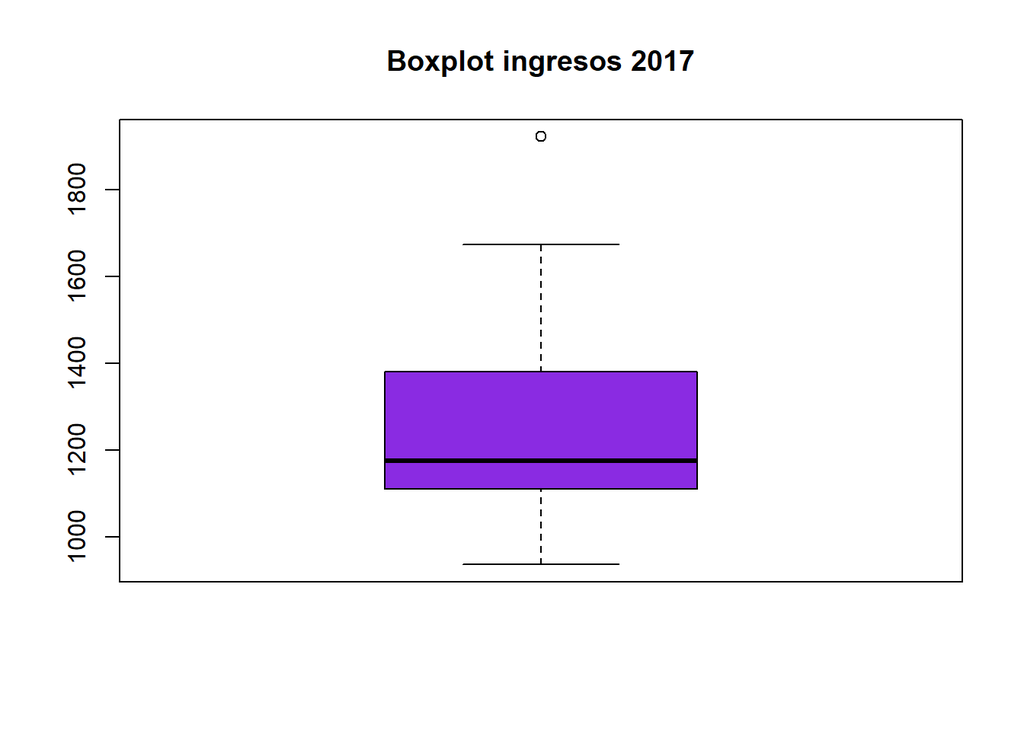

```
El boxplot del 2017 presenta 1 valores atípico. Este valor corresponde a la siguiente región y promedio de ingresos mensuales.
```

1921.26–> Moquegua

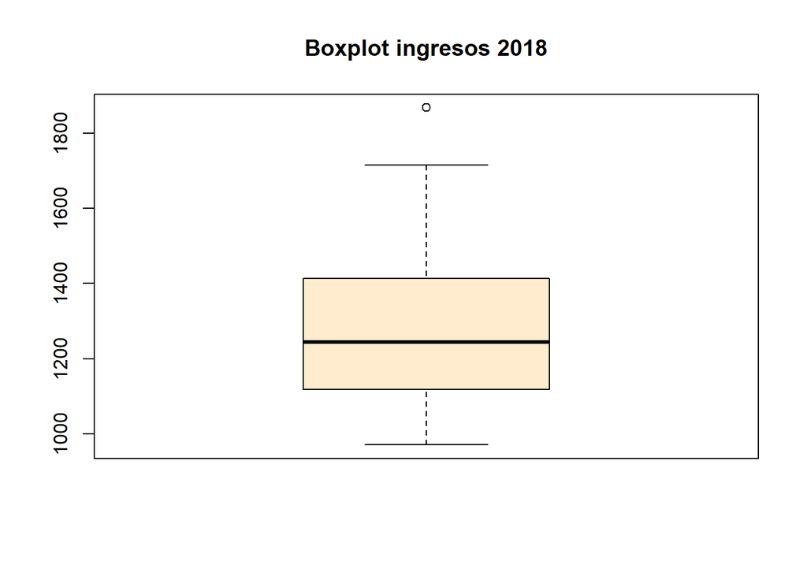

```
El boxplot del 2018 presenta 1 valores atípico. Este valor corresponde a la siguiente región y promedio de ingresos mensuales.
```

1867.9–> Moquegua

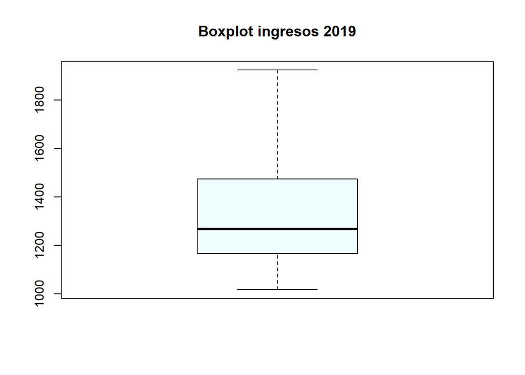

El boxplot del 2019 no presenta valores atípicos. Se puede concluir que se cuenta con valores no muy alejados de ingresos por región.

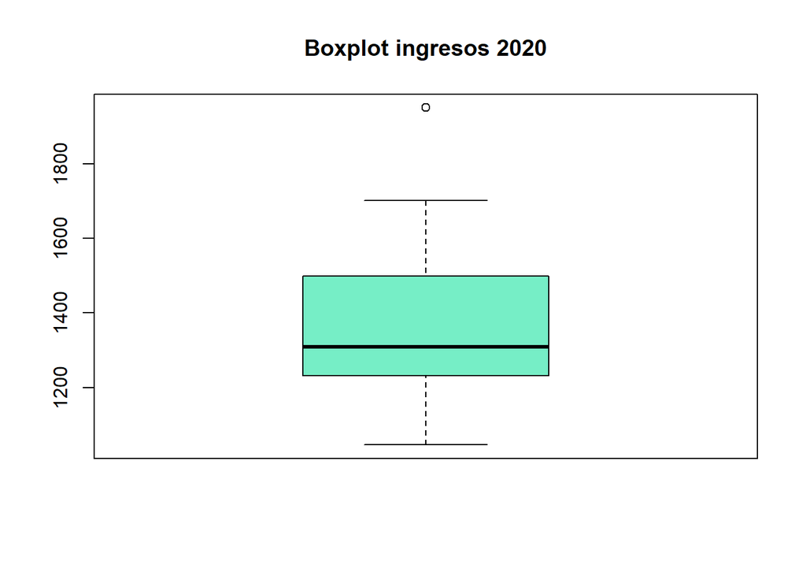

```
El boxplot del 2020 presenta 1 valores atípico. Este valor corresponde a la siguiente región y promedio de ingresos mensuales.
```

1950.97 –> Moquegua

Podemos concluir en cuanto a las gráficas de barras que en casi todos los años se mantiene que Moquegua y Lima ocupan los espacios con mayores ingresos mensuales. Asimismo, las regiones o departamentos con menor ingreso promedio en soles son Huánuco, Apurímac, Huancavelica y Puno en la mayoría de casos.

En cuanto a los boxplots quisimos en esta entrega resaltar 2 boxplots más que cuentan con valores atípicos. Como podemos ver en ambos los valores atípicos pertenecen a Lima y Moquegua (departamentos con mayor ingreso por cada año). Esto se debe a la brecha de ingreso respecto a las otras regiones tanto para el 2012 y 2014.

*INTERVALOS DE CONFIANZA PARA LA MEDIA POBLACIONAL DE LOS INGRESOS POR AÑO*

Los intervalos de confianza seguirán una distribución Z, ya que la muestra para cada año es mayor a 30, por lo cual siguiendo la regla práctica utilizaremos esta distribución.

Los intervalos de confianza serán aplicados con un 95% de nivel de confianza y un 5% de nivel de significancia.

- Trabajar con un 95% de nivel de confianza se refiere a que dentro de las muestras tomadas en 95% de los casos el valor de la media poblacional se encontrará dentro de los intervalos de confianza.
- El 5% refiere a que dentro de las muestras tomadas en el 5% de los casos no se encontrará dentro de los intervalos de confianza creados.

Comenzamos calculando la media de todos los datos de ingresos para cada año.

mm = media muestral

*Medias muestrales por año*

```
## [1] "mm04 -->"
```

```
## [1] 587.6421
```

```
## [1] "mm05 -->"
```

```
## [1] 589.3681
```

```
## [1] "mm06 -->"
```

```
## [1] 643.0657
```

```
## [1] "mm07 -->"
```

```
## [1] 714.9706
```

```
## [1] "mm08 -->"
```

```
## [1] 769.0496
```

```
## [1] "mm09 -->"
```

```
## [1] 836.1292
```

```
## [1] "mm10 -->"
```

```
## [1] 852.1115
```

```
## [1] "mm11 -->"
```

```
## [1] 917.9449
```

```
## [1] "mm12 -->"
```

```
## [1] 993.862
```

```
## [1] "mm13 -->"
```

```
## [1] 1090.103
```

```
## [1] "mm14 -->"
```

```
## [1] 1167.816
```

```
## [1] "mm15 -->"
```

```
## [1] 1218.939
```

```
## [1] "mm16 -->"
```

```
## [1] 1302.456
```

```
## [1] "mm17 -->"
```

```
## [1] 1332.435
```

```
## [1] "mm18 -->"
```

```
## [1] 1374.479
```

```
## [1] "mm19 -->"
```

```
## [1] 1406.908
```

```
## [1] "mm20 -->"
```

```
## [1] 1410.71
```

Asimismo calculamos la desviación estándar de todos los datos de ingresos para cada año.

sd = desviación estándar muestral

*Desviaciones estándar muestrales por año*

```
## [1] "sd04 -->"
```

```
## [1] 787.2187
```

```
## [1] "sd05 -->"
```

```
## [1] 790.2166
```

```
## [1] "sd06 -->"
```

```
## [1] 776.9593
```

```
## [1] "sd07 -->"
```

```
## [1] 848.4402
```

```
## [1] "sd08 -->"
```

```
## [1] 868.4074
```

```
## [1] "sd09 -->"
```

```
## [1] 950.9827
```

```
## [1] "sd10 -->"
```

```
## [1] 993.5723
```

```
## [1] "sd11 -->"
```

```
## [1] 961.2884
```

```
## [1] "sd12 -->"
```

```
## [1] 996.7451
```

```
## [1] "sd13 -->"
```

```
## [1] 1076.478
```

```
## [1] "sd14 -->"
```

```
## [1] 1130.624
```

```
## [1] "sd15 -->"
```

```
## [1] 1210.685
```

```
## [1] "sd16 -->"
```

```
## [1] 1318.072
```

```
## [1] "sd17 -->"
```

```
## [1] 1297.203
```

```
## [1] "sd18 -->"
```

```
## [1] 1278.056
```

```
## [1] "sd19 -->"
```

```
## [1] 1334.073
```

```
## [1] "sd20 -->"
```

```
## [1] 1388.532
```

Con los datos calculados previamente y encontrando la Z a/2 con la siguiente función “Z<-qnorm(0.025, lower.tail = FALSE)” podremos encontrar los intervalos de confianza para la media poblacional para cada año.

*Intervalos de confianza*

```
## [1] "Intervalo de confianza para la media poblacional 2004:  574.38 , 600.9"
```

```
## [1] "Intervalo de confianza para la media poblacional 2005:  575.91 , 602.83"
```

```
## [1] "Intervalo de confianza para la media poblacional 2006:  630.64 , 655.49"
```

```
## [1] "Intervalo de confianza para la media poblacional 2007:  702.35 , 727.59"
```

```
## [1] "Intervalo de confianza para la media poblacional 2008:  755.98 , 782.12"
```

```
## [1] "Intervalo de confianza para la media poblacional 2009:  821.95 , 850.31"
```

```
## [1] "Intervalo de confianza para la media poblacional 2010:  837.25 , 866.97"
```

```
## [1] "Intervalo de confianza para la media poblacional 2011:  904.43 , 931.46"
```

```
## [1] "Intervalo de confianza para la media poblacional 2012:  980.18 , 1007.54"
```

```
## [1] "Intervalo de confianza para la media poblacional 2013:  1076.78 , 1103.42"
```

```
## [1] "Intervalo de confianza para la media poblacional 2014:  1153.82 , 1181.81"
```

```
## [1] "Intervalo de confianza para la media poblacional 2015:  1203.95 , 1233.93"
```

```
## [1] "Intervalo de confianza para la media poblacional 2016:  1287.07 , 1317.84"
```

```
## [1] "Intervalo de confianza para la media poblacional 2017:  1316.82 , 1348.05"
```

```
## [1] "Intervalo de confianza para la media poblacional 2018:  1359.47 , 1389.49"
```

```
## [1] "Intervalo de confianza para la media poblacional 2019:  1390.74 , 1423.08"
```

```
## [1] "Intervalo de confianza para la media poblacional 2020:  1391.94 , 1429.48"
```

*Pruebas de hipotesis*

Realizamos 3 pruebas de hipótesis:

*Prueba de hipótesis 1*

“La media del 2007 será mayor que el de la media correspondiente del año 2005”

[figure not shown]

Establecimos que se cumpliría la hipótesis nula en caso la media del 2007 sea menor a la del 2005 y en el caso contrario se afirma la hipótesis alternativa.

Calculamos el valor crítico con la función qnorm tomando como parámetro el área hasta llegar al valor Za/2 de la derecha, ya que como buscamos comprobar que la media correspondiente al 2007 es *mayor* a la del 2005, utilizaremos el lado derecho de la gráfica normal estándar. Esto nos dio un valor crítico de 1.64

*A partir de esto se rechaza la hipótesis nula y se confirma la hipótesis alternativa.*

*Prueba de hipótesis 2*

La media del 2019 es diferente a la del 2018

La media a lo largo de los años es creciente para la mayoría de estos, ninguno de los resultados se mantiene igual dos años consecutivos. Por ello, se puede asumir que la media del 2019 será diferente a la del 2018.

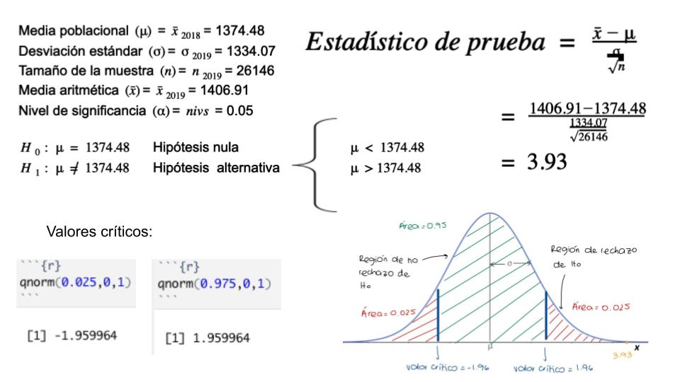

Para esta prueba de hipótesis utilizamos media muestral del 2018, lo cual es = 1374.48 soles Agrupamos los datos para el 2019 como se puede apreciar en la imagen (desviación estándar muestral la cual estamos tomando como poblacional debido a que usaremos el modelo z (justificado previamente), tamaño de la muestra, media aritmética muestral, nivel de significancia).

Establecimos que se cumpliría la hipótesis nula en caso la media del 2019 sea igual a la del 2018 y en el caso contrario se afirma la hipótesis alternativa (cuando sea mayor o menor al valor de la media del 2018).

Ya que estamos buscando comprobar que sea mayor o menor a la media del 2018, utilizaremos la cola negativa y la cola positiva de la gráfica normal estándar Calculamos los valor críticos con la función qnorm tomando como parámetro el área hasta llegar al valor -Za/2 de la izquierda y Za/2 de la derecha. Estos valores críticos nos dieron= -1.95 y 1.95

Luego de esto calculamos el estadístico de prueba reemplazando los datos agrupados y este dio como resultado = 3.93, el cual se encuentra a la derecha del valor crítico#2 o en la región de rechazo de la hipótesis nula.

*A partir de esto se rechaza la hipótesis nula y se confirma la hipótesis alternativa.*

*Prueba de hipótesis 3*

La media del 2012 será menor que la media del 2015

Como mencionado anteriormente, la media conforme pasan los años varía con una pendiente positiva. En ningún momento se ve una disminución sustancial de la media en el cambio de un año al otro.

[figure not shown]

Para esta prueba de hipótesis utilizamos media muestral del 2015, lo cual es = 1218.94 soles Agrupamos los datos para el 2012 como se puede apreciar en la imagen (desviación estándar muestral la cual estamos tomando como poblacional debido a que usaremos el modelo z (justificado previamente), tamaño de la muestra, media aritmética muestral, nivel de significancia).

Establecimos que se cumpliría la hipótesis nula en caso la media del 2012 sea mayor o igual a la del 2015 y en el caso contrario se afirma la hipótesis alternativa.

Ya que estamos buscando comprobar que sea menor a la media del 2015, utilizaremos la cola negativa de la gráfica normal estándar Calculamos el valor crítico con la función qnorm tomando como parámetro el área hasta llegar al valor -Za/2 de la izquierda. Este valor crítico nos dio= -1.64

*A partir de esto se rechaza la hipótesis nula y se confirma la hipótesis alternativa.*

*REGRESIÓN*

*VARIABLES DEPENDIENTES*

Se han utilizado 3 pares de variables dependientes para esta presentación: - Año de Encuesta e Ingreso Promedio Mensual - Tiempo de Trabajo Semanal Promedio e Ingreso Promedio Mensual - Año de encuesta y Trabajadores Promedio en una empresa por región

# Análisis de Regresión:

- Para todas las pruebas de hipótesis de regresión, se ha tomado un nivel de significancia de 5%.
1. Ingreso Mensual Promedio vs Año de Encuesta

Test de hipótesis (para todas las regiones):

$H_0: \beta = 0$ $H_A: \beta \neq 0$

Donde $\beta$ es el coeficiente de la variable independiente, “Año de Encuesta”.

Como se puede observar para Amazonas, el valor-p es de $8.42e-14$, permitiendo concluir que se rechaza la $H_0$. En base al valor de $r^2$, se puede concluir que alrededor del $97.7%$ de la variabilidad del ingreso promedio mensual se puede explicar con el año de la encuesta.

```
##
## Call:
## lm(formula = promedioAm ~ anos, data = Am.data)
##
## Residuals:
##     Min      1Q  Median      3Q     Max
## -50.652 -29.948  -2.582  17.294  77.110
##
## Coefficients:
##              Estimate Std. Error t value Pr(>|t|)
## (Intercept) -98802.60    3882.58  -25.45 9.38e-14 ***
## anos            49.47       1.93   25.64 8.42e-14 ***
## ---
## Signif. codes:  0 '***' 0.001 '**' 0.01 '*' 0.05 '.' 0.1 ' ' 1
##
## Residual standard error: 38.98 on 15 degrees of freedom
## Multiple R-squared:  0.9777, Adjusted R-squared:  0.9762
## F-statistic: 657.2 on 1 and 15 DF,  p-value: 8.418e-14
```

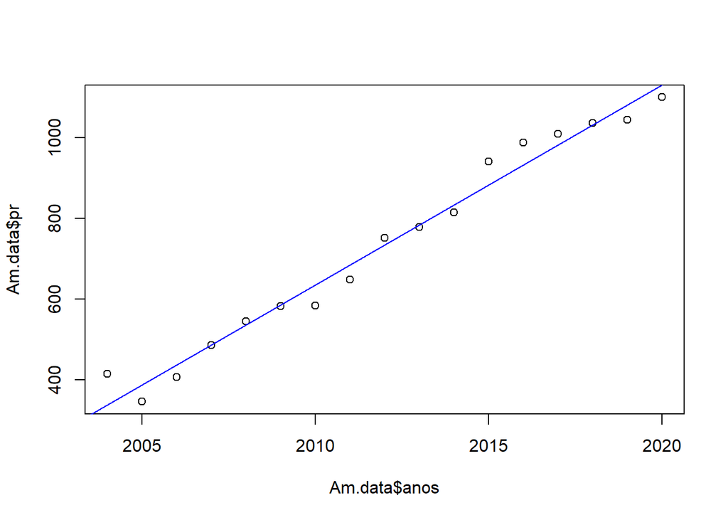

Como se puede observar para Ancash, el valor-p es de $1.39e-12$, permitiendo concluir que se rechaza la $H_0$. En base al valor de $r^2$, se puede concluir que alrededor del $96.7$% de la variabilidad del ingreso promedio mensual se puede explicar con el año de la encuesta.

```
##
## Call:
## lm(formula = promedioAn ~ anos, data = An.data)
##
## Residuals:
##      Min       1Q   Median       3Q      Max
## -112.299  -17.993    6.436   29.551   80.695
##
## Coefficients:
##               Estimate Std. Error t value Pr(>|t|)
## (Intercept) -97585.019   4653.060  -20.97 1.58e-12 ***
## anos            48.944      2.313   21.16 1.39e-12 ***
## ---
## Signif. codes:  0 '***' 0.001 '**' 0.01 '*' 0.05 '.' 0.1 ' ' 1
##
## Residual standard error: 46.71 on 15 degrees of freedom
## Multiple R-squared:  0.9676, Adjusted R-squared:  0.9654
## F-statistic: 447.9 on 1 and 15 DF,  p-value: 1.388e-12
```

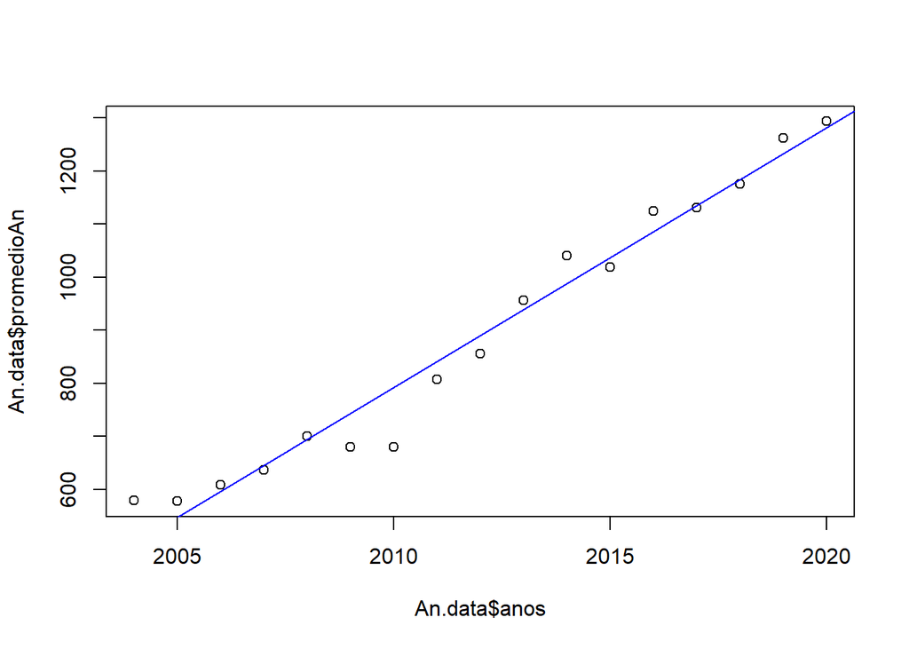

Como se puede observar para Apurimac, el valor-p es de $8.47e-08$, permitiendo concluir que se rechaza la $H_0$. En base al valor de $r^2$, se puede concluir que alrededor del $86$% de la variabilidad del ingreso promedio mensual se puede explicar con el año de la encuesta.

```
##
## Call:
## lm(formula = promedioAp ~ anos, data = Ap.data)
##
## Residuals:
##     Min      1Q  Median      3Q     Max
## -179.86  -52.73  -12.40   63.39  192.90
##
## Coefficients:
##               Estimate Std. Error t value Pr(>|t|)
## (Intercept) -87476.917   9187.225  -9.522 9.49e-08 ***
## anos            43.857      4.566   9.605 8.47e-08 ***
## ---
## Signif. codes:  0 '***' 0.001 '**' 0.01 '*' 0.05 '.' 0.1 ' ' 1
##
## Residual standard error: 92.23 on 15 degrees of freedom
## Multiple R-squared:  0.8601, Adjusted R-squared:  0.8508
## F-statistic: 92.25 on 1 and 15 DF,  p-value: 8.471e-08
```

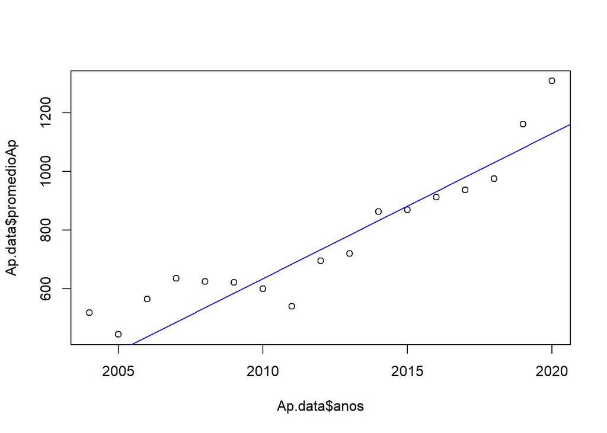

Como se puede observar para Arequipa, el valor-p es de $2.74e-13$, permitiendo concluir que se rechaza la $H_0$. En base al valor de $r^2$, se puede concluir que alrededor del $97.4$% de la variabilidad del ingreso promedio mensual se puede explicar con el año de la encuesta.

```
##
## Call:
## lm(formula = promedioAr ~ anos, data = Ar.data)
##
## Residuals:
##      Min       1Q   Median       3Q      Max
## -109.196  -26.841    8.941   25.008  120.136
##
## Coefficients:
##               Estimate Std. Error t value Pr(>|t|)
## (Intercept) -1.356e+05  5.776e+03  -23.47 3.08e-13 ***
## anos         6.790e+01  2.871e+00   23.65 2.74e-13 ***
## ---
## Signif. codes:  0 '***' 0.001 '**' 0.01 '*' 0.05 '.' 0.1 ' ' 1
##
## Residual standard error: 57.99 on 15 degrees of freedom
## Multiple R-squared:  0.9739, Adjusted R-squared:  0.9721
## F-statistic: 559.4 on 1 and 15 DF,  p-value: 2.744e-13
```

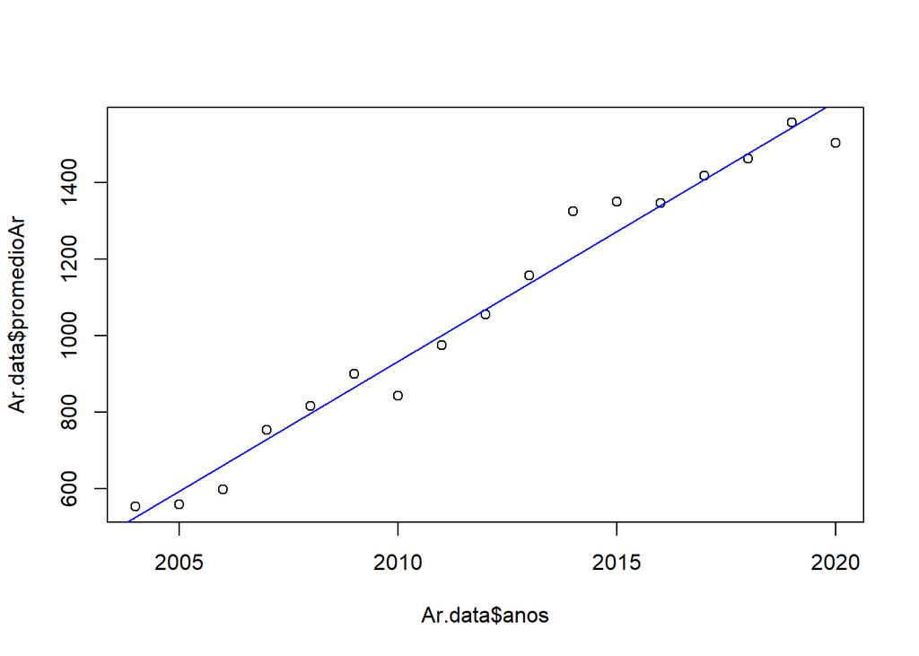

Como se puede observar para Ayacucho, el valor-p es de $7.30e-12$, permitiendo concluir que se rechaza la $H_0$. En base al valor de $r^2$, se puede concluir que alrededor del $96.0$% de la variabilidad del ingreso promedio mensual se puede explicar con el año de la encuesta.

```
##
## Call:
## lm(formula = promedioAy ~ anos, data = Ay.data)
##
## Residuals:
##    Min     1Q Median     3Q    Max
## -63.88 -30.39 -12.35  23.73  92.06
##
## Coefficients:
##              Estimate Std. Error t value Pr(>|t|)
## (Intercept) -89960.13    4809.56  -18.70 8.31e-12 ***
## anos            45.11       2.39   18.87 7.30e-12 ***
## ---
## Signif. codes:  0 '***' 0.001 '**' 0.01 '*' 0.05 '.' 0.1 ' ' 1
##
## Residual standard error: 48.28 on 15 degrees of freedom
## Multiple R-squared:  0.9596, Adjusted R-squared:  0.9569
## F-statistic: 356.2 on 1 and 15 DF,  p-value: 7.303e-12
```

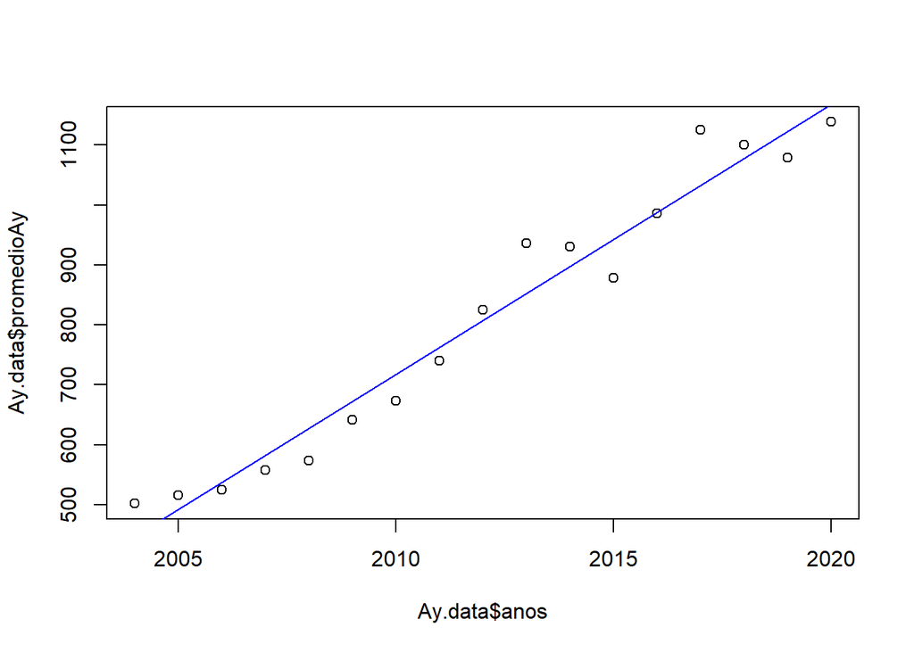

Como se puede observar para Cajamarca, el valor-p es de $2.15e-13$, permitiendo concluir que se rechaza la $H_0$. En base al valor de $r^2$, se puede concluir que alrededor del $97.5$% de la variabilidad del ingreso promedio mensual se puede explicar con el año de la encuesta.

```
##
## Call:
## lm(formula = promedioCa ~ anos, data = Ca.data)
##
## Residuals:
##     Min      1Q  Median      3Q     Max
## -73.048 -30.354  -7.211  34.892  93.625
##
## Coefficients:
##               Estimate Std. Error t value Pr(>|t|)
## (Intercept) -1.052e+05  4.410e+03  -23.85 2.42e-13 ***
## anos         5.270e+01  2.192e+00   24.05 2.15e-13 ***
## ---
## Signif. codes:  0 '***' 0.001 '**' 0.01 '*' 0.05 '.' 0.1 ' ' 1
##
## Residual standard error: 44.27 on 15 degrees of freedom
## Multiple R-squared:  0.9747, Adjusted R-squared:  0.973
## F-statistic: 578.3 on 1 and 15 DF,  p-value: 2.151e-13
```

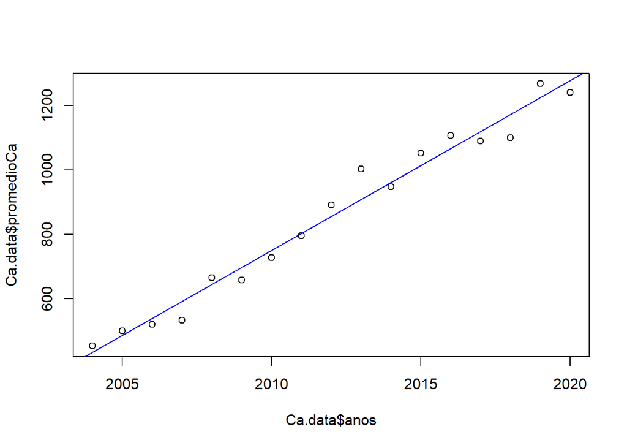

Como se puede observar para Callao, el valor-p es de $1.59e-11$, permitiendo concluir que se rechaza la $H_0$. En base al valor de $r^2$, se puede concluir que alrededor del $95.5$% de la variabilidad del ingreso promedio mensual se puede explicar con el año de la encuesta.

```
##
## Call:
## lm(formula = promedioCall ~ anos, data = Call.data)
##
## Residuals:
##     Min      1Q  Median      3Q     Max
## -105.99  -41.28    4.16   36.29  110.42
##
## Coefficients:
##               Estimate Std. Error t value Pr(>|t|)
## (Intercept) -1.148e+05  6.490e+03  -17.70 1.84e-11 ***
## anos         5.766e+01  3.226e+00   17.88 1.59e-11 ***
## ---
## Signif. codes:  0 '***' 0.001 '**' 0.01 '*' 0.05 '.' 0.1 ' ' 1
##
## Residual standard error: 65.15 on 15 degrees of freedom
## Multiple R-squared:  0.9552, Adjusted R-squared:  0.9522
## F-statistic: 319.5 on 1 and 15 DF,  p-value: 1.595e-11
```

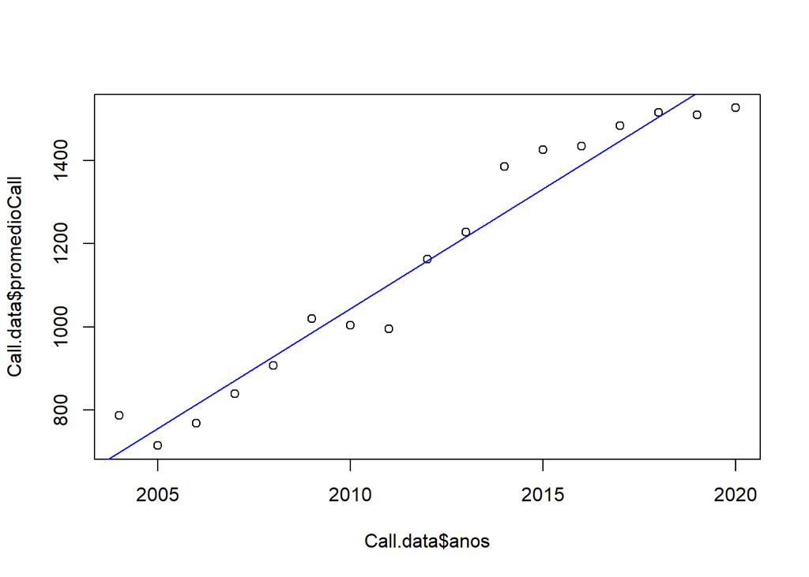

Como se puede observar para Cusco, el valor-p es de $7.46e-15$, permitiendo concluir que se rechaza la $H_0$. En base al valor de $r^2$, se puede concluir que alrededor del $98.4$% de la variabilidad del ingreso promedio mensual se puede explicar con el año de la encuesta.

```
##
## Call:
## lm(formula = promedioCusco ~ anos, data = Cusco.data)
##
## Residuals:
##     Min      1Q  Median      3Q     Max
## -64.372 -29.212  -8.095  37.734  63.185
##
## Coefficients:
##               Estimate Std. Error t value Pr(>|t|)
## (Intercept) -1.292e+05  4.308e+03  -30.00 8.33e-15 ***
## anos         6.471e+01  2.141e+00   30.22 7.46e-15 ***
## ---
## Signif. codes:  0 '***' 0.001 '**' 0.01 '*' 0.05 '.' 0.1 ' ' 1
##
## Residual standard error: 43.25 on 15 degrees of freedom
## Multiple R-squared:  0.9838, Adjusted R-squared:  0.9828
## F-statistic: 913.2 on 1 and 15 DF,  p-value: 7.464e-15
```

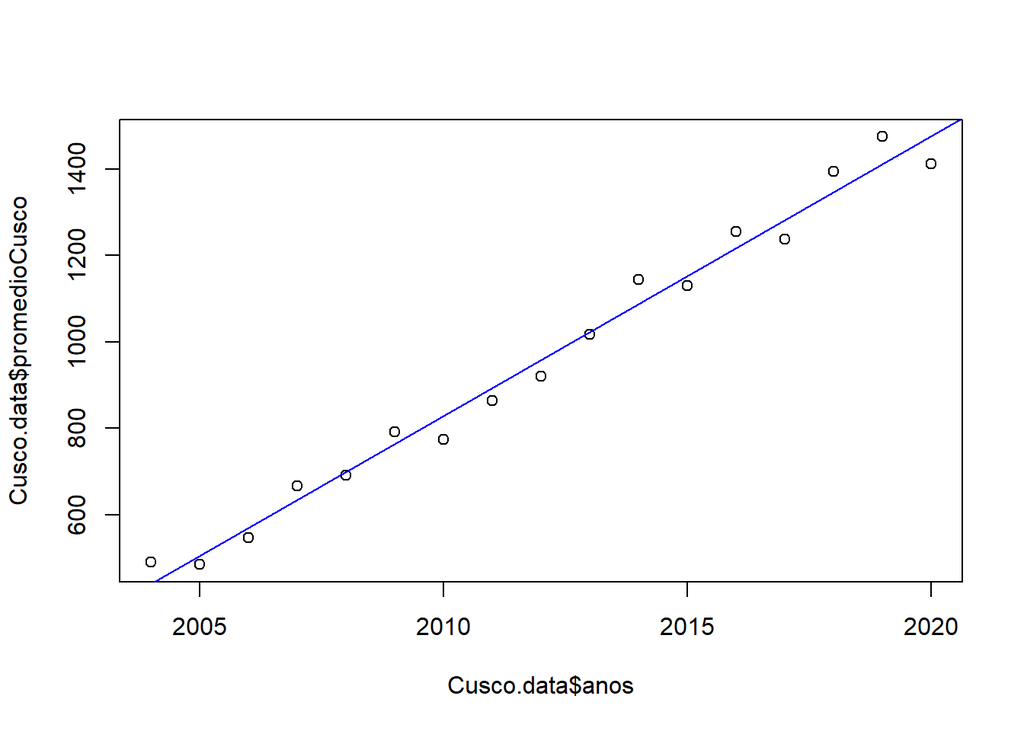

Como se puede observar para Huancavelica, el valor-p es de $1.41e-07$, permitiendo concluir que se rechaza la $H_0$. En base al valor de $r^2$, se puede concluir que alrededor del $85$% de la variabilidad del ingreso promedio mensual se puede explicar con el año de la encuesta.

```
##
## Call:
## lm(formula = promedioHua ~ anos, data = Hua.data)
##
## Residuals:
##     Min      1Q  Median      3Q     Max
## -137.60  -44.75   10.47   40.48  133.11
##
## Coefficients:
##               Estimate Std. Error t value Pr(>|t|)
## (Intercept) -58335.226   6409.661  -9.101 1.70e-07 ***
## anos            29.411      3.186   9.232 1.41e-07 ***
## ---
## Signif. codes:  0 '***' 0.001 '**' 0.01 '*' 0.05 '.' 0.1 ' ' 1
##
## Residual standard error: 64.35 on 15 degrees of freedom
## Multiple R-squared:  0.8504, Adjusted R-squared:  0.8404
## F-statistic: 85.23 on 1 and 15 DF,  p-value: 1.414e-07
```

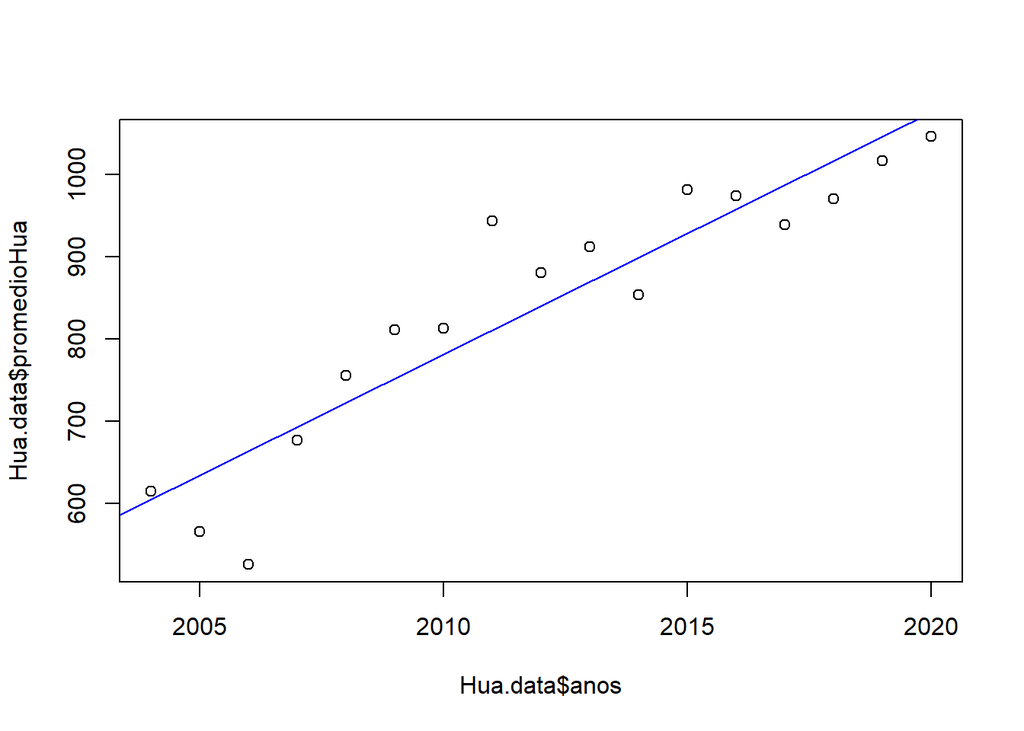

Como se puede observar para Huánuco, el valor-p es de $1.21e-11$, permitiendo concluir que se rechaza la $H_0$. En base al valor de $r^2$, se puede concluir que alrededor del $95.7$% de la variabilidad del ingreso promedio mensual se puede explicar con el año de la encuesta.

```
##
## Call:
## lm(formula = promedioHuan ~ anos, data = Huan.data)
##
## Residuals:
##    Min     1Q Median     3Q    Max
## -94.32 -45.43  12.86  49.80  78.77
##
## Coefficients:
##               Estimate Std. Error t value Pr(>|t|)
## (Intercept) -1.006e+05  5.563e+03  -18.08 1.35e-11 ***
## anos         5.038e+01  2.765e+00   18.22 1.21e-11 ***
## ---
## Signif. codes:  0 '***' 0.001 '**' 0.01 '*' 0.05 '.' 0.1 ' ' 1
##
## Residual standard error: 55.85 on 15 degrees of freedom
## Multiple R-squared:  0.9568, Adjusted R-squared:  0.9539
## F-statistic: 332.1 on 1 and 15 DF,  p-value: 1.21e-11
```

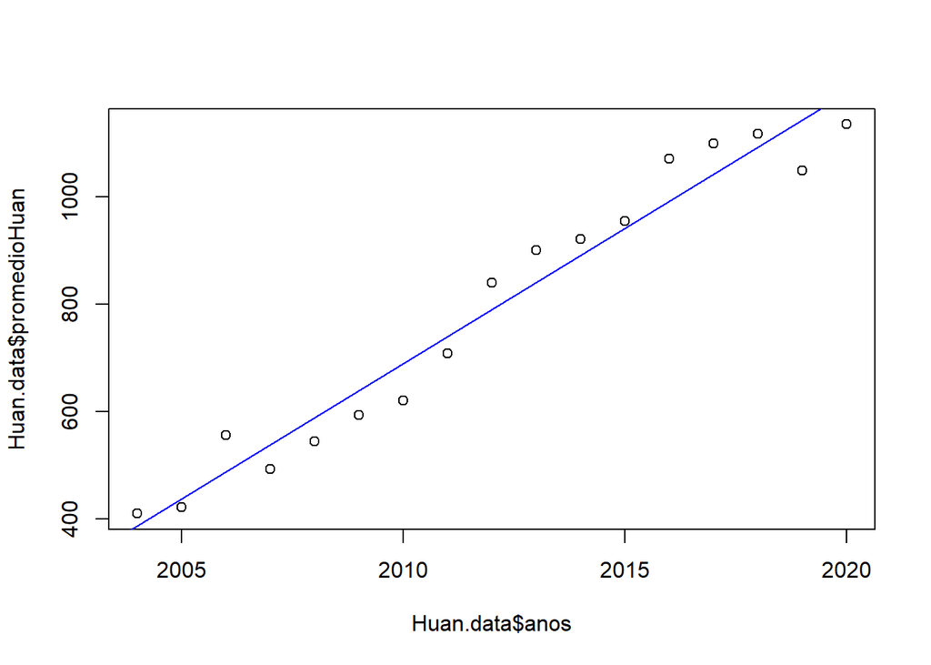

Como se puede observar para Ica, el valor-p es de $1.64e-15$, permitiendo concluir que se rechaza la $H_0$. En base al valor de $r^2$, se puede concluir que alrededor del $98.7$% de la variabilidad del ingreso promedio mensual se puede explicar con el año de la encuesta.

```
##
## Call:
## lm(formula = promedioI ~ anos, data = I.data)
##
## Residuals:
##    Min     1Q Median     3Q    Max
## -65.49 -33.89  10.21  24.70  71.89
##
## Coefficients:
##               Estimate Std. Error t value Pr(>|t|)
## (Intercept) -1.212e+05  3.649e+03  -33.20 1.85e-15 ***
## anos         6.072e+01  1.814e+00   33.48 1.64e-15 ***
## ---
## Signif. codes:  0 '***' 0.001 '**' 0.01 '*' 0.05 '.' 0.1 ' ' 1
##
## Residual standard error: 36.63 on 15 degrees of freedom
## Multiple R-squared:  0.9868, Adjusted R-squared:  0.9859
## F-statistic:  1121 on 1 and 15 DF,  p-value: 1.642e-15
```

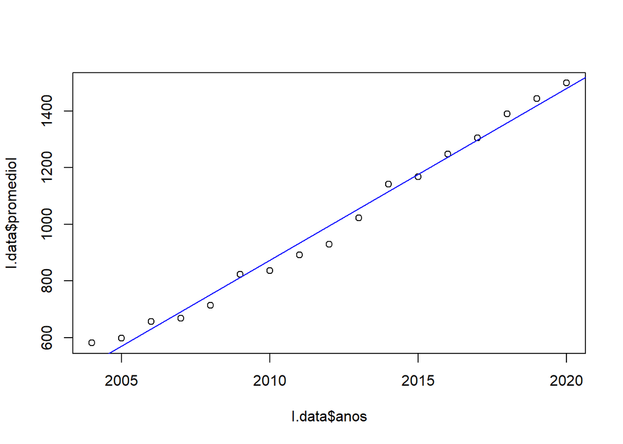

Como se puede observar para Junin, el valor-p es de $6.11e-12$, permitiendo concluir que se rechaza la $H_0$. En base al valor de $r^2$, se puede concluir que alrededor del $96.1$% de la variabilidad del ingreso promedio mensual se puede explicar con el año de la encuesta.

```
##
## Call:
## lm(formula = promedioJu ~ anos, data = Ju.data)
##
## Residuals:
##     Min      1Q  Median      3Q     Max
## -81.738 -32.632  -2.178  44.171  76.242
##
## Coefficients:
##               Estimate Std. Error t value Pr(>|t|)
## (Intercept) -92224.274   4874.978  -18.92 7.05e-12 ***
## anos            46.295      2.423   19.11 6.11e-12 ***
## ---
## Signif. codes:  0 '***' 0.001 '**' 0.01 '*' 0.05 '.' 0.1 ' ' 1
##
## Residual standard error: 48.94 on 15 degrees of freedom
## Multiple R-squared:  0.9605, Adjusted R-squared:  0.9579
## F-statistic: 365.1 on 1 and 15 DF,  p-value: 6.11e-12
```

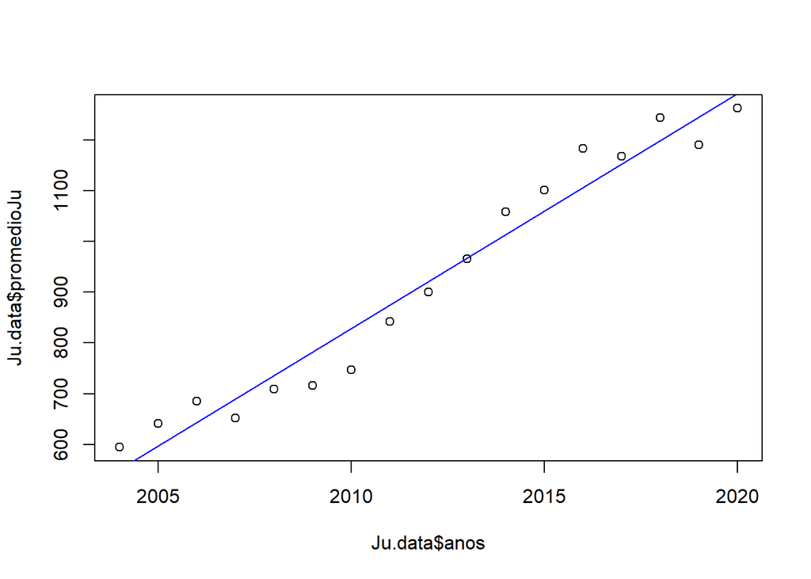

```
##
## Call:
## lm(formula = promedioLa ~ anos, data = La.data)
##
## Residuals:
##     Min      1Q  Median      3Q     Max
## -68.704 -21.723   7.707  20.808  44.004
##
## Coefficients:
##              Estimate Std. Error t value Pr(>|t|)
## (Intercept) -97690.71    3098.27  -31.53 3.98e-15 ***
## anos            49.01       1.54   31.83 3.47e-15 ***
## ---
## Signif. codes:  0 '***' 0.001 '**' 0.01 '*' 0.05 '.' 0.1 ' ' 1
##
## Residual standard error: 31.1 on 15 degrees of freedom
## Multiple R-squared:  0.9854, Adjusted R-squared:  0.9844
## F-statistic:  1013 on 1 and 15 DF,  p-value: 3.47e-15
```

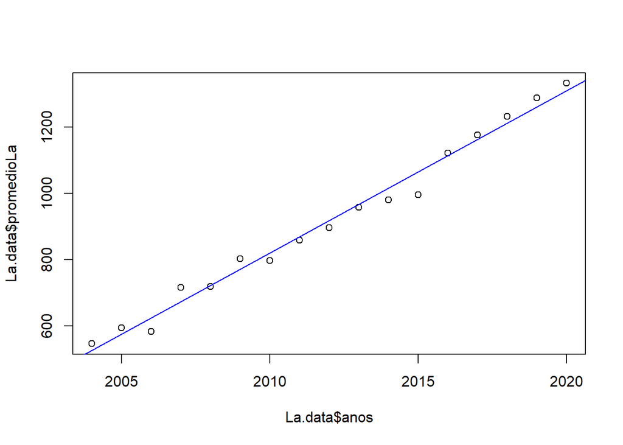

Como se puede observar para Lambayeque, el valor-p es de $1.1e-14$, permitiendo concluir que se rechaza la $H_0$. En base al valor de $r^2$, se puede concluir que alrededor del $98.3$% de la variabilidad del ingreso promedio mensual se puede explicar con el año de la encuesta.

```
##
## Call:
## lm(formula = promedioLambayeque ~ anos, data = Lambayeque.data)
##
## Residuals:
##    Min     1Q Median     3Q    Max
## -69.39 -21.20  -4.87  15.70  89.03
##
## Coefficients:
##               Estimate Std. Error t value Pr(>|t|)
## (Intercept) -1.088e+05  3.726e+03  -29.20 1.24e-14 ***
## anos         5.449e+01  1.852e+00   29.43 1.10e-14 ***
## ---
## Signif. codes:  0 '***' 0.001 '**' 0.01 '*' 0.05 '.' 0.1 ' ' 1
##
## Residual standard error: 37.4 on 15 degrees of freedom
## Multiple R-squared:  0.983,  Adjusted R-squared:  0.9818
## F-statistic: 866.1 on 1 and 15 DF,  p-value: 1.104e-14
```

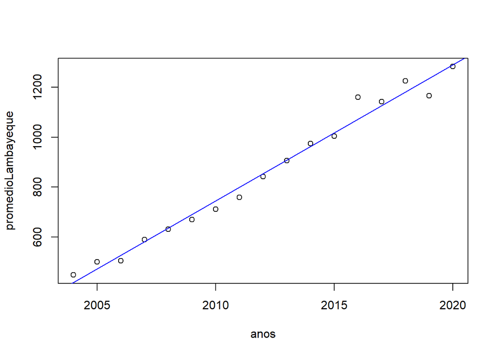

Como se puede observar para Lima, el valor-p es de $2.2e-12$, permitiendo concluir que se rechaza la $H_0$. En base al valor de $r^2$, se puede concluir que alrededor del $96.6$% de la variabilidad del ingreso promedio mensual se puede explicar con el año de la encuesta.

```
##
## Call:
## lm(formula = promedioLima ~ anos, data = Lima.data)
##
## Residuals:
##      Min       1Q   Median       3Q      Max
## -148.745  -44.282   -4.852   33.982  157.238
##
## Coefficients:
##               Estimate Std. Error t value Pr(>|t|)
## (Intercept) -1.403e+05  6.906e+03  -20.32 2.51e-12 ***
## anos         7.037e+01  3.432e+00   20.50 2.20e-12 ***
## ---
## Signif. codes:  0 '***' 0.001 '**' 0.01 '*' 0.05 '.' 0.1 ' ' 1
##
## Residual standard error: 69.33 on 15 degrees of freedom
## Multiple R-squared:  0.9655, Adjusted R-squared:  0.9632
## F-statistic: 420.4 on 1 and 15 DF,  p-value: 2.202e-12
```

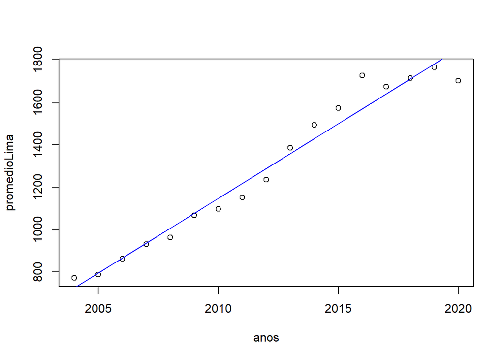

Como se puede observar para Loreto, el valor-p es de $1.65e-12$, permitiendo concluir que se rechaza la $H_0$. En base al valor de $r^2$, se puede concluir que alrededor del $96.7$% de la variabilidad del ingreso promedio mensual se puede explicar con el año de la encuesta.

```
##
## Call:
## lm(formula = promedioLoreto ~ anos, data = Loreto.data)
##
## Residuals:
##      Min       1Q   Median       3Q      Max
## -107.437  -48.977   -4.128   54.069  133.482
##
## Coefficients:
##               Estimate Std. Error t value Pr(>|t|)
## (Intercept) -1.322e+05  6.369e+03  -20.75 1.85e-12 ***
## anos         6.620e+01  3.166e+00   20.91 1.65e-12 ***
## ---
## Signif. codes:  0 '***' 0.001 '**' 0.01 '*' 0.05 '.' 0.1 ' ' 1
##
## Residual standard error: 63.94 on 15 degrees of freedom
## Multiple R-squared:  0.9668, Adjusted R-squared:  0.9646
## F-statistic: 437.3 on 1 and 15 DF,  p-value: 1.653e-12
```

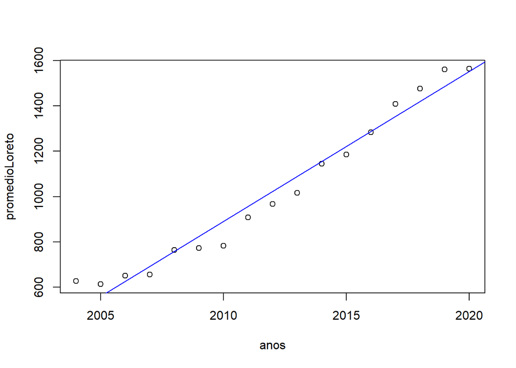

```
##
## Call:
## lm(formula = promedioMadreDeDios ~ anos, data = MadreDeDios.data)
##
## Residuals:
##     Min      1Q  Median      3Q     Max
## -91.335 -35.499  -1.575  21.521  86.870
##
## Coefficients:
##               Estimate Std. Error t value Pr(>|t|)
## (Intercept) -114491.83    4767.74  -24.01 2.20e-13 ***
## anos             57.45       2.37   24.24 1.91e-13 ***
## ---
## Signif. codes:  0 '***' 0.001 '**' 0.01 '*' 0.05 '.' 0.1 ' ' 1
##
## Residual standard error: 47.86 on 15 degrees of freedom
## Multiple R-squared:  0.9751, Adjusted R-squared:  0.9735
## F-statistic: 587.7 on 1 and 15 DF,  p-value: 1.911e-13
```

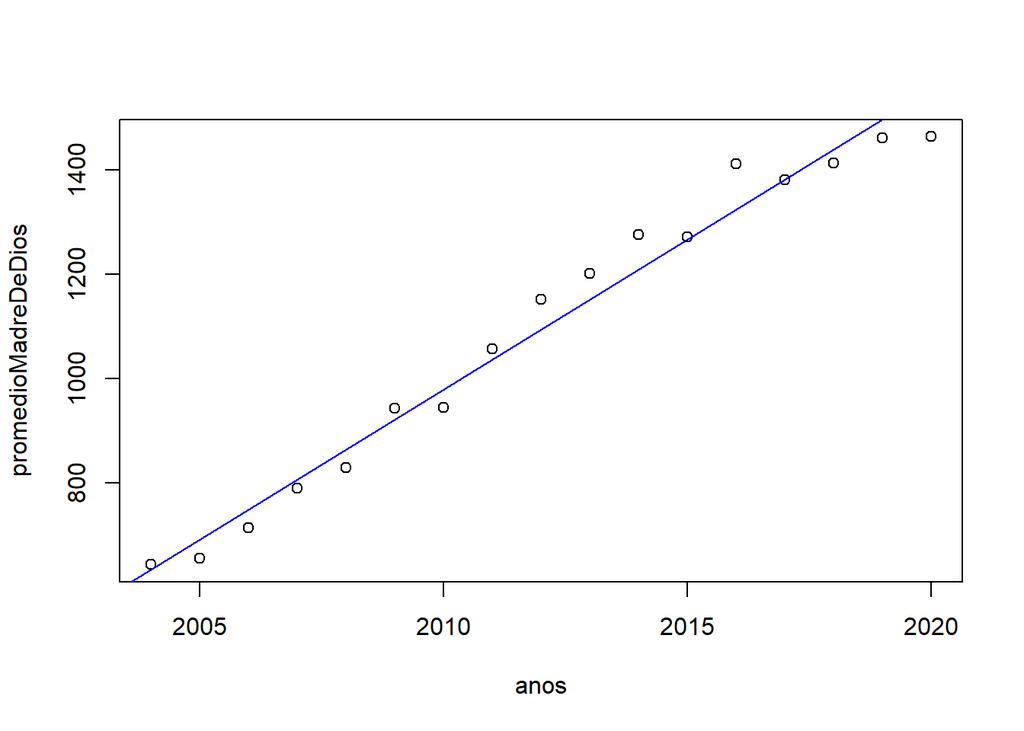

Como se puede observar para Moquegua, el valor-p es de $5.62e-10$, permitiendo concluir que se rechaza la $H_0$. En base al valor de $r^2$, se puede concluir que alrededor del $92.8$% de la variabilidad del ingreso promedio mensual se puede explicar con el año de la encuesta.

```
##
## Call:
## lm(formula = promedioMoquegua ~ anos, data = Moquegua.data)
##
## Residuals:
##     Min      1Q  Median      3Q     Max
## -173.26 -117.05   24.31   86.69  263.94
##
## Coefficients:
##               Estimate Std. Error t value Pr(>|t|)
## (Intercept) -1.664e+05  1.207e+04  -13.79 6.35e-10 ***
## anos         8.341e+01  5.998e+00   13.91 5.62e-10 ***
## ---
## Signif. codes:  0 '***' 0.001 '**' 0.01 '*' 0.05 '.' 0.1 ' ' 1
##
## Residual standard error: 121.2 on 15 degrees of freedom
## Multiple R-squared:  0.928,  Adjusted R-squared:  0.9232
## F-statistic: 193.4 on 1 and 15 DF,  p-value: 5.623e-10
```

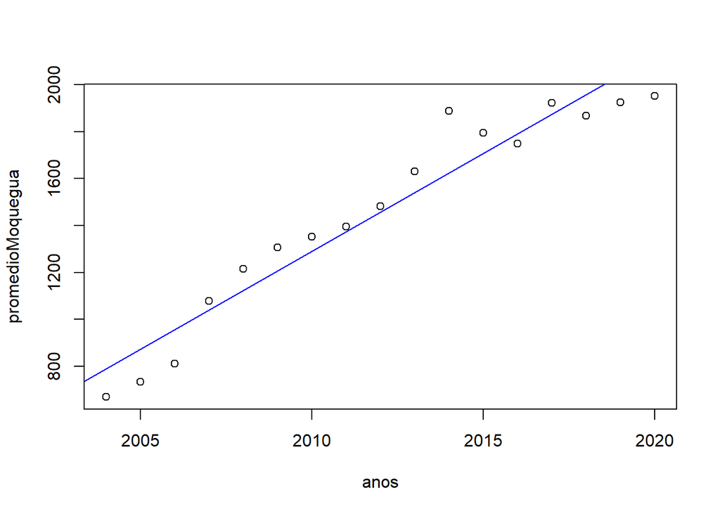

Como se puede observar para Pacso, el valor-p es de $1.13e-11$, permitiendo concluir que se rechaza la $H_0$. En base al valor de $r^2$, se puede concluir que alrededor del $95.7$% de la variabilidad del ingreso promedio mensual se puede explicar con el año de la encuesta.

```
##
## Call:
## lm(formula = promedioPasco ~ anos, data = Pasco.data)
##
## Residuals:
##     Min      1Q  Median      3Q     Max
## -87.041 -39.438  -1.793  37.716  66.431
##
## Coefficients:
##               Estimate Std. Error t value Pr(>|t|)
## (Intercept) -85112.397   4699.204  -18.11 1.32e-11 ***
## anos            42.768      2.336   18.31 1.13e-11 ***
## ---
## Signif. codes:  0 '***' 0.001 '**' 0.01 '*' 0.05 '.' 0.1 ' ' 1
##
## Residual standard error: 47.18 on 15 degrees of freedom
## Multiple R-squared:  0.9572, Adjusted R-squared:  0.9543
## F-statistic: 335.3 on 1 and 15 DF,  p-value: 1.128e-11
```

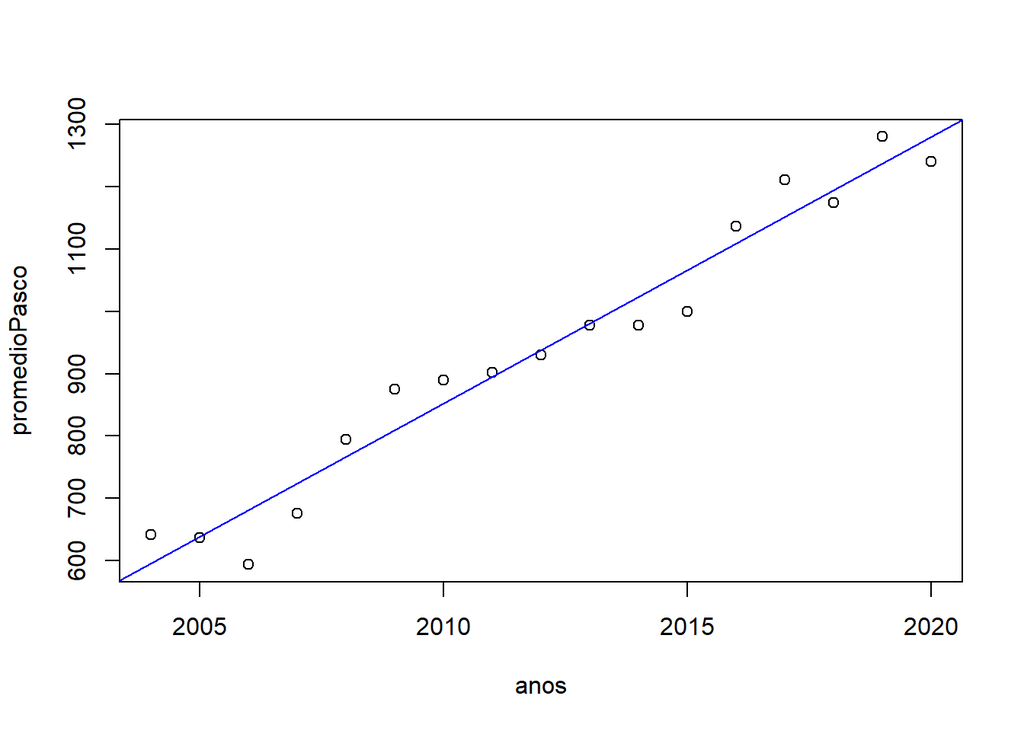

```
##
## Call:
## lm(formula = promedioPiura ~ anos, data = Piura.data)
##
## Residuals:
##     Min      1Q  Median      3Q     Max
## -82.301 -28.294  -9.135  16.171  86.389
##
## Coefficients:
##               Estimate Std. Error t value Pr(>|t|)
## (Intercept) -106371.33    4244.73  -25.06 1.18e-13 ***
## anos             53.30       2.11   25.26 1.04e-13 ***
## ---
## Signif. codes:  0 '***' 0.001 '**' 0.01 '*' 0.05 '.' 0.1 ' ' 1
##
## Residual standard error: 42.61 on 15 degrees of freedom
## Multiple R-squared:  0.977,  Adjusted R-squared:  0.9755
## F-statistic: 638.3 on 1 and 15 DF,  p-value: 1.043e-13
```

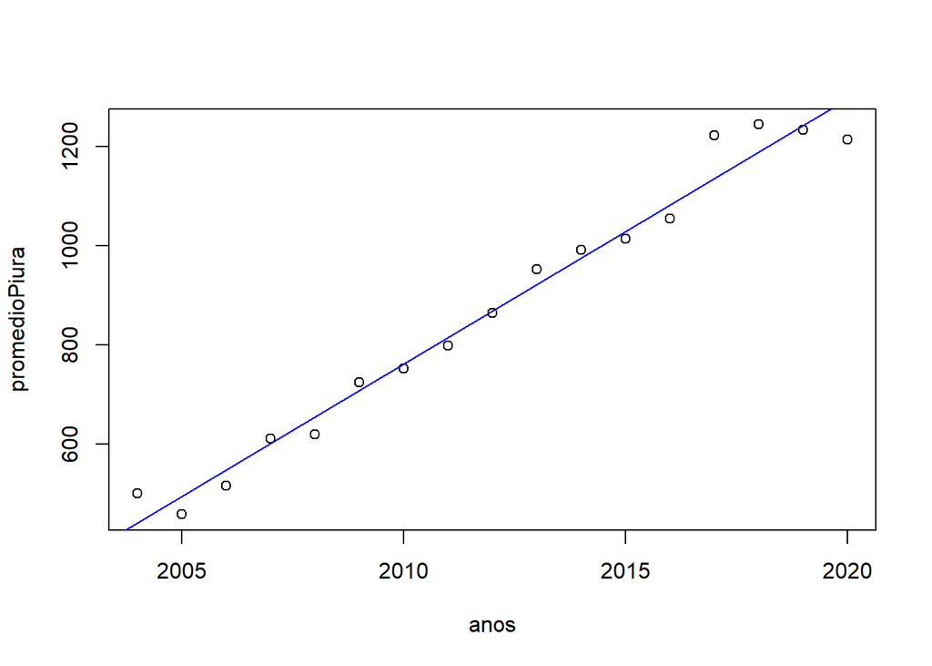

Como se puede observar para Puno, el valor-p es de $1.57e-10$, permitiendo concluir que se rechaza la $H_0$. En base al valor de $r^2$, se puede concluir que alrededor del $93.9$% de la variabilidad del ingreso promedio mensual se puede explicar con el año de la encuesta.

```
##
## Call:
## lm(formula = promedioPuno ~ anos, data = Puno.data)
##
## Residuals:
##    Min     1Q Median     3Q    Max
## -75.45 -38.18 -14.53  23.87 108.08
##
## Coefficients:
##               Estimate Std. Error t value Pr(>|t|)
## (Intercept) -84403.330   5594.733  -15.09 1.79e-10 ***
## anos            42.343      2.781   15.23 1.57e-10 ***
## ---
## Signif. codes:  0 '***' 0.001 '**' 0.01 '*' 0.05 '.' 0.1 ' ' 1
##
## Residual standard error: 56.17 on 15 degrees of freedom
## Multiple R-squared:  0.9392, Adjusted R-squared:  0.9352
## F-statistic: 231.9 on 1 and 15 DF,  p-value: 1.569e-10
```

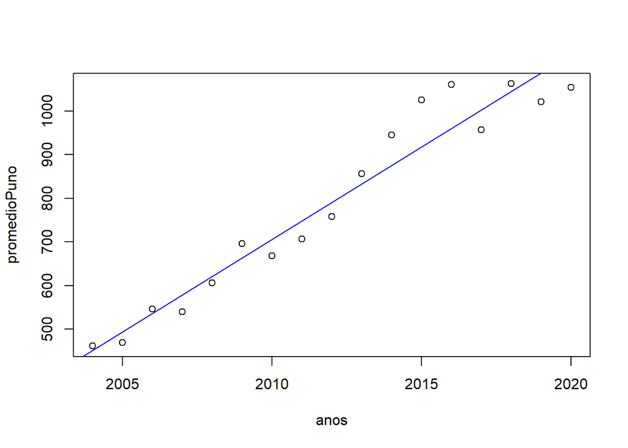

Como se puede observar para San Martin, el valor-p es de $8.93e-12$, permitiendo concluir que se rechaza la $H_0$. En base al valor de $r^2$, se puede concluir que alrededor del $95.9$% de la variabilidad del ingreso promedio mensual se puede explicar con el año de la encuesta.

```
##
## Call:
## lm(formula = promedioSanMartin ~ anos, data = SanMartin.data)
##
## Residuals:
##     Min      1Q  Median      3Q     Max
## -133.20  -33.28   11.03   32.43   91.19
##
## Coefficients:
##               Estimate Std. Error t value Pr(>|t|)
## (Intercept) -110718.38    5994.92  -18.47 9.97e-12 ***
## anos             55.45       2.98   18.61 8.93e-12 ***
## ---
## Signif. codes:  0 '***' 0.001 '**' 0.01 '*' 0.05 '.' 0.1 ' ' 1
##
## Residual standard error: 60.18 on 15 degrees of freedom
## Multiple R-squared:  0.9585, Adjusted R-squared:  0.9557
## F-statistic: 346.4 on 1 and 15 DF,  p-value: 8.925e-12
```

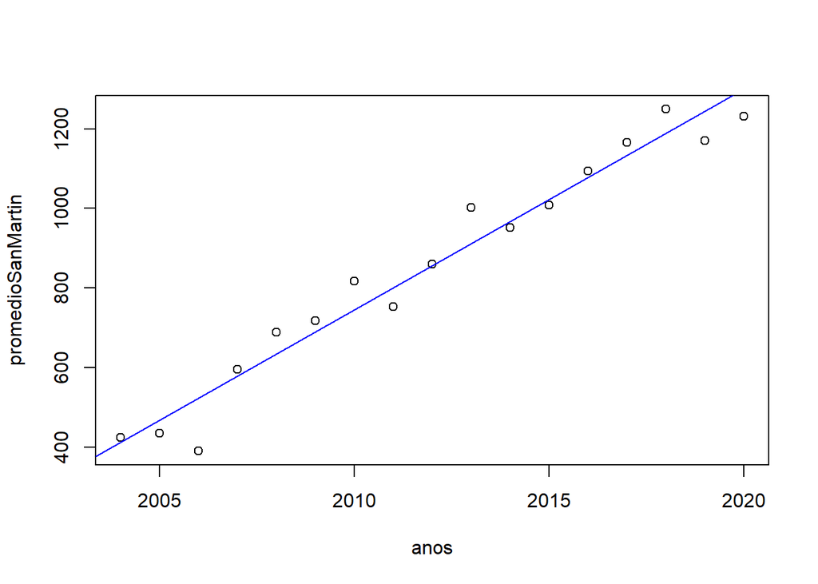

Como se puede observar para Tacna, el valor-p es de $1.1e-12$, permitiendo concluir que se rechaza la $H_0$. En base al valor de $r^2$, se puede concluir que alrededor del $96.9$% de la variabilidad del ingreso promedio mensual se puede explicar con el año de la encuesta.

```
##
## Call:
## lm(formula = promedioTacna ~ anos, data = Tacna.data)
##
## Residuals:
##     Min      1Q  Median      3Q     Max
## -136.31  -38.34   14.19   44.83   68.37
##
## Coefficients:
##               Estimate Std. Error t value Pr(>|t|)
## (Intercept) -122168.09    5734.89   -21.3 1.26e-12 ***
## anos             61.30       2.85    21.5 1.10e-12 ***
## ---
## Signif. codes:  0 '***' 0.001 '**' 0.01 '*' 0.05 '.' 0.1 ' ' 1
##
## Residual standard error: 57.57 on 15 degrees of freedom
## Multiple R-squared:  0.9686, Adjusted R-squared:  0.9665
## F-statistic: 462.5 on 1 and 15 DF,  p-value: 1.1e-12
```

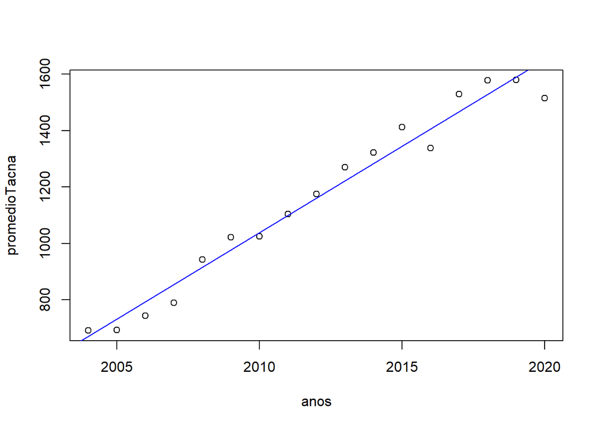

Como se puede observar para Tumbes, el valor-p es de $4.16e-13$, permitiendo concluir que se rechaza la $H_0$. En base al valor de $r^2$, se puede concluir que alrededor del $97.2$% de la variabilidad del ingreso promedio mensual se puede explicar con el año de la encuesta.

```
##
## Call:
## lm(formula = promedioTumbes ~ anos, data = Tumbes.data)
##
## Residuals:
##     Min      1Q  Median      3Q     Max
## -98.922 -36.660   8.178  34.239  73.678
##
## Coefficients:
##               Estimate Std. Error t value Pr(>|t|)
## (Intercept) -1.221e+05  5.357e+03  -22.80 4.68e-13 ***
## anos         6.120e+01  2.663e+00   22.99 4.16e-13 ***
## ---
## Signif. codes:  0 '***' 0.001 '**' 0.01 '*' 0.05 '.' 0.1 ' ' 1
##
## Residual standard error: 53.78 on 15 degrees of freedom
## Multiple R-squared:  0.9724, Adjusted R-squared:  0.9706
## F-statistic: 528.4 on 1 and 15 DF,  p-value: 4.162e-13
```

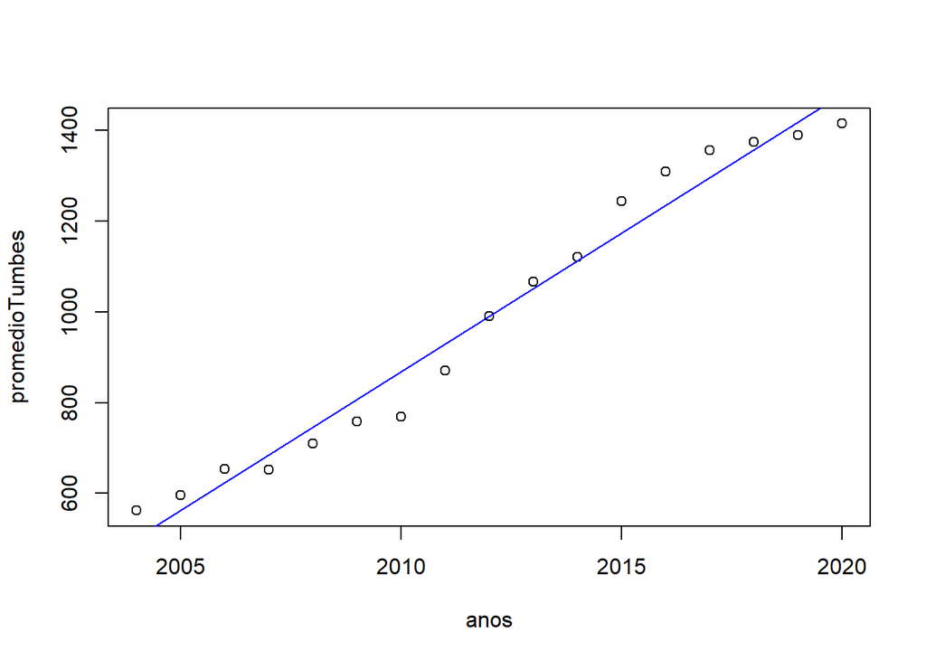

Como se puede observar para Ucayali, el valor-p es de $8.98e-13$, permitiendo concluir que se rechaza la $H_0$. En base al valor de $r^2$, se puede concluir que alrededor del $96.9$% de la variabilidad del ingreso promedio mensual se puede explicar con el año de la encuesta.

```
##
## Call:
## lm(formula = promedioUcayali ~ anos, data = Ucayali.data)
##
## Residuals:
##     Min      1Q  Median      3Q     Max
## -70.277 -33.148   6.644  22.713  94.674
##
## Coefficients:
##               Estimate Std. Error t value Pr(>|t|)
## (Intercept) -99038.589   4582.557  -21.61 1.02e-12 ***
## anos            49.669      2.278   21.81 8.98e-13 ***
## ---
## Signif. codes:  0 '***' 0.001 '**' 0.01 '*' 0.05 '.' 0.1 ' ' 1
##
## Residual standard error: 46.01 on 15 degrees of freedom
## Multiple R-squared:  0.9694, Adjusted R-squared:  0.9674
## F-statistic: 475.6 on 1 and 15 DF,  p-value: 8.976e-13
```

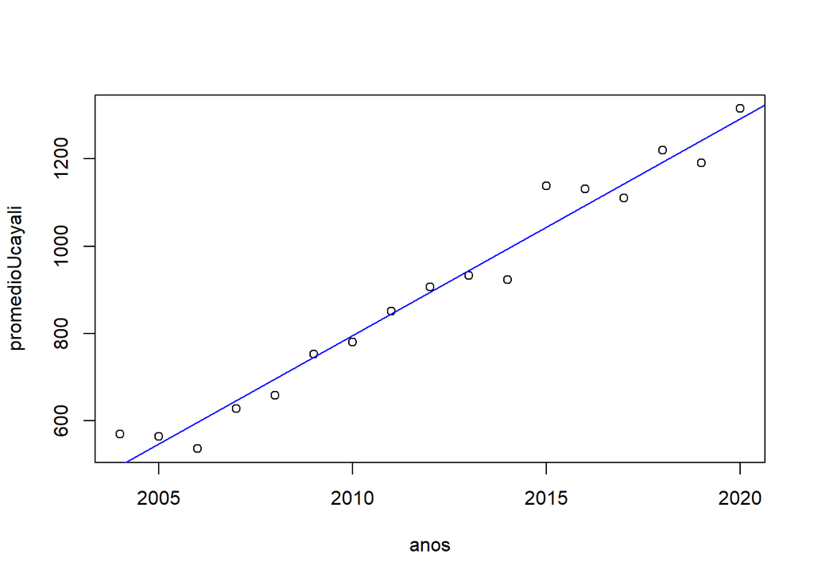

### Análisis de Regresión Año de Encuesta vs Ingreso Promedio Mensual

Con los valores de $r^2$ y p-valores obtenidos, podemos concluir que hay una relación extremadamente fuerte entre el año de la encuesta contra el ingreso promedio mensual del encuestado. Esto se debe a que todas las regiones han obtenido valores de $r^2$ mayores a 0.8 y valores p muy por debajo del nivel de significancia de 0.05.

2. Tiempo de Trabajo Semanal vs Ingreso Promedio Mensual

Test de hipótesis (para todas las regiones):

$H_0: \beta = 0$ $H_A: \beta \neq 0$

Donde $\beta$ es el coeficiente de la variable independiente, “Tiempo de Trabajo Semanal”.

Como se puede observar para Amazonas, el valor-p es de $0.09$, permitiendo concluir que no se rechaza la $H_0$. En base al valor de $r^2$, se puede concluir que alrededor del $17.9$% de la variabilidad del ingreso promedio mensual se puede explicar con el año de la encuesta.

```
##
## Call:
## lm(formula = promedioAm ~ promedio_trabajoAmazonas, data = AmazonasTI)
##
## Residuals:
##     Min      1Q  Median      3Q     Max
## -333.53 -230.62   58.67  196.28  350.73
##
## Coefficients:
##                          Estimate Std. Error t value Pr(>|t|)
## (Intercept)              -2044.81    1535.52  -1.332   0.2028
## promedio_trabajoAmazonas    88.46      48.85   1.811   0.0902 .
## ---
## Signif. codes:  0 '***' 0.001 '**' 0.01 '*' 0.05 '.' 0.1 ' ' 1
##
## Residual standard error: 236.4 on 15 degrees of freedom
## Multiple R-squared:  0.1794, Adjusted R-squared:  0.1247
## F-statistic: 3.279 on 1 and 15 DF,  p-value: 0.09024
```

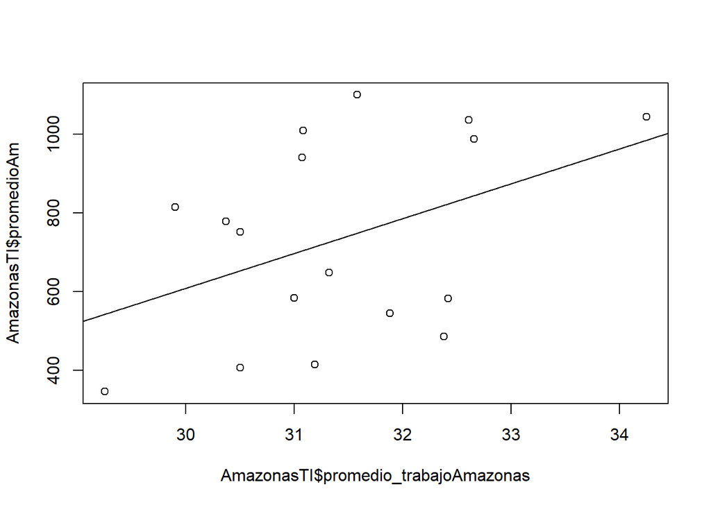

Como se puede observar para Ancash, el valor-p es de $0.001$, permitiendo concluir que se rechaza la $H_0$. En base al valor de $r^2$, se puede concluir que alrededor del $54.1$% de la variabilidad del ingreso promedio mensual se puede explicar con el año de la encuesta.

```
##
## Call:
## lm(formula = promedioAm ~ promedio_trabajoAncash, data = AncashTI)
##
## Residuals:
##     Min      1Q  Median      3Q     Max
## -249.64 -117.97  -44.83  155.31  302.79
##
## Coefficients:
##                        Estimate Std. Error t value Pr(>|t|)
## (Intercept)             3723.83     732.51   5.084 0.000167 ***
## promedio_trabajoAncash   -88.13      21.70  -4.062 0.001166 **
## ---
## Signif. codes:  0 '***' 0.001 '**' 0.01 '*' 0.05 '.' 0.1 ' ' 1
##
## Residual standard error: 173.1 on 14 degrees of freedom
##   (1 observation deleted due to missingness)
## Multiple R-squared:  0.541,  Adjusted R-squared:  0.5082
## F-statistic:  16.5 on 1 and 14 DF,  p-value: 0.001166
```

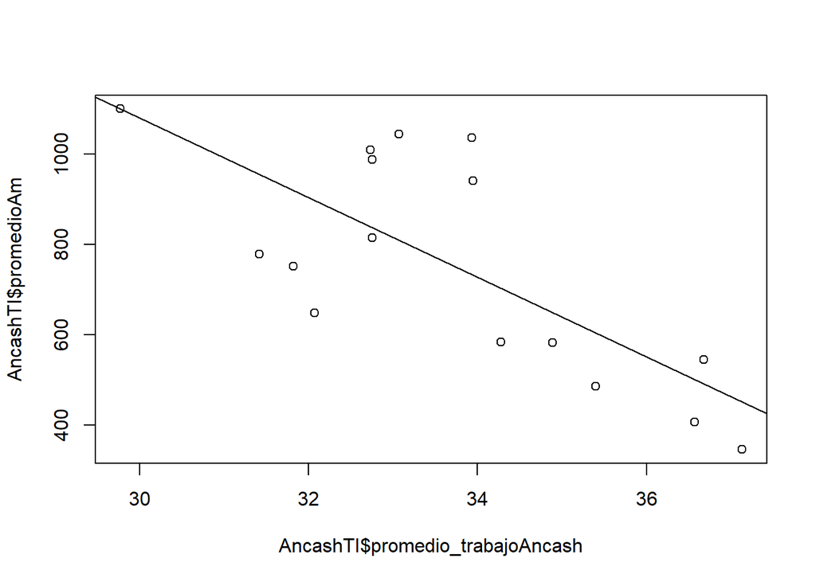

Como se puede observar para Apurimac, el valor-p es de $0.06$, permitiendo concluir que no se rechaza la $H_0$. En base al valor de $r^2$, se puede concluir que alrededor del $23.6$% de la variabilidad del ingreso promedio mensual se puede explicar con el año de la encuesta.

```
##
## Call:
## lm(formula = promedioAp ~ promedio_trabajoApurimac, data = ApurimacTI)
##
## Residuals:
##     Min      1Q  Median      3Q     Max
## -394.79 -170.06   14.52  131.10  384.86
##
## Coefficients:
##                          Estimate Std. Error t value Pr(>|t|)
## (Intercept)               2219.99     695.18   3.193  0.00651 **
## promedio_trabajoApurimac   -46.85      22.54  -2.078  0.05658 .
## ---
## Signif. codes:  0 '***' 0.001 '**' 0.01 '*' 0.05 '.' 0.1 ' ' 1
##
## Residual standard error: 215.2 on 14 degrees of freedom
##   (1 observation deleted due to missingness)
## Multiple R-squared:  0.2357, Adjusted R-squared:  0.1812
## F-statistic: 4.318 on 1 and 14 DF,  p-value: 0.05658
```

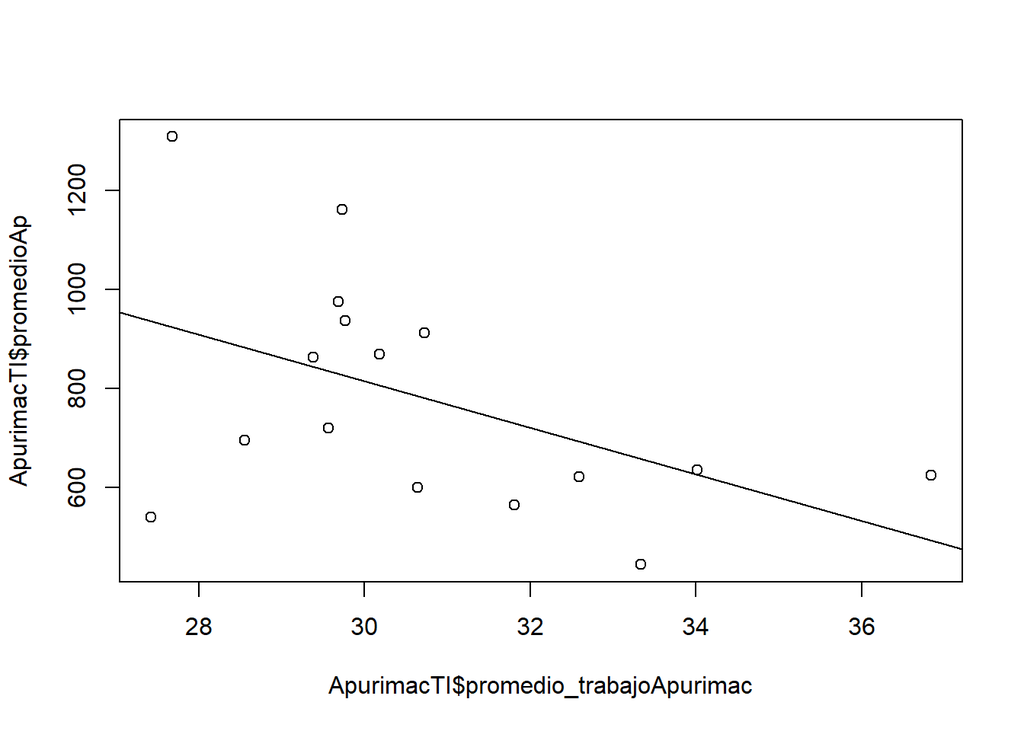

Como se puede observar para Arequipa, el valor-p es de $0.02$, permitiendo concluir que se rechaza la $H_0$. En base al valor de $r^2$, se puede concluir que alrededor del $33.3$% de la variabilidad del ingreso promedio mensual se puede explicar con el año de la encuesta.

```
##
## Call:
## lm(formula = promedioAr ~ promedio_trabajoArequipa, data = ArequipaTI)
##
## Residuals:
##     Min      1Q  Median      3Q     Max
## -395.65 -142.33  -41.55   85.98  743.56
##
## Coefficients:
##                          Estimate Std. Error t value Pr(>|t|)
## (Intercept)              -4641.85    2172.14  -2.137   0.0507 .
## promedio_trabajoArequipa   140.79      53.23   2.645   0.0192 *
## ---
## Signif. codes:  0 '***' 0.001 '**' 0.01 '*' 0.05 '.' 0.1 ' ' 1
##
## Residual standard error: 280.2 on 14 degrees of freedom
##   (1 observation deleted due to missingness)
## Multiple R-squared:  0.3332, Adjusted R-squared:  0.2856
## F-statistic: 6.996 on 1 and 14 DF,  p-value: 0.01921
```

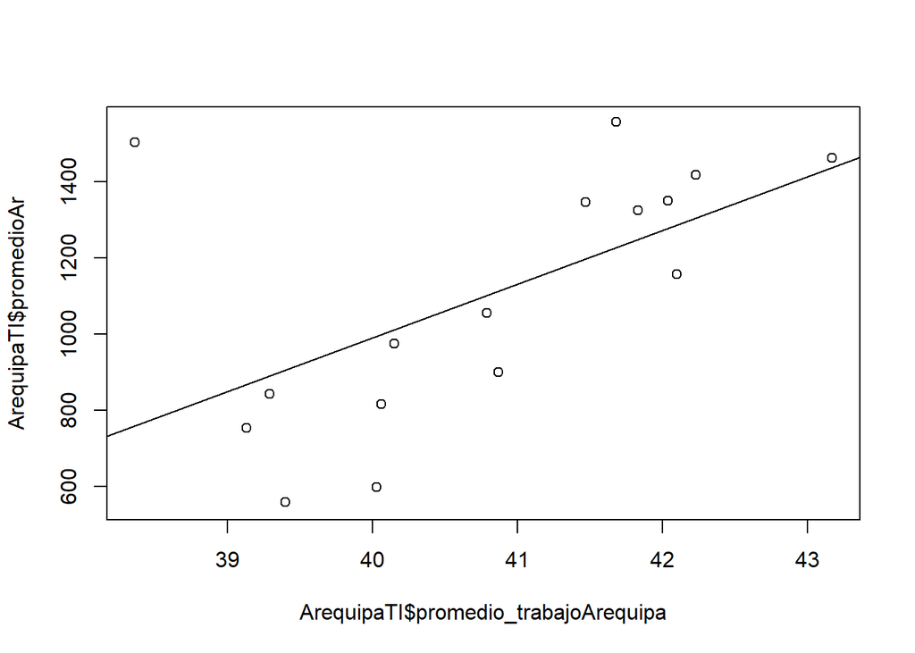

Como se puede observar para Ayacucho, el valor-p es de $0.04$, permitiendo concluir que se rechaza la $H_0$. En base al valor de $r^2$, se puede concluir que alrededor del $27.0$% de la variabilidad del ingreso promedio mensual se puede explicar con el año de la encuesta.

```
##
## Call:
## lm(formula = promedioAy ~ promedio_trabajoAyacucho, data = AyacuchoTI)
##
## Residuals:
##    Min     1Q Median     3Q    Max
## -310.6 -162.8   17.7  170.7  266.4
##
## Coefficients:
##                          Estimate Std. Error t value Pr(>|t|)
## (Intercept)               3548.68    1198.13   2.962   0.0103 *
## promedio_trabajoAyacucho   -80.67      35.47  -2.274   0.0392 *
## ---
## Signif. codes:  0 '***' 0.001 '**' 0.01 '*' 0.05 '.' 0.1 ' ' 1
##
## Residual standard error: 199.9 on 14 degrees of freedom
##   (1 observation deleted due to missingness)
## Multiple R-squared:  0.2697, Adjusted R-squared:  0.2176
## F-statistic: 5.171 on 1 and 14 DF,  p-value: 0.03923
```

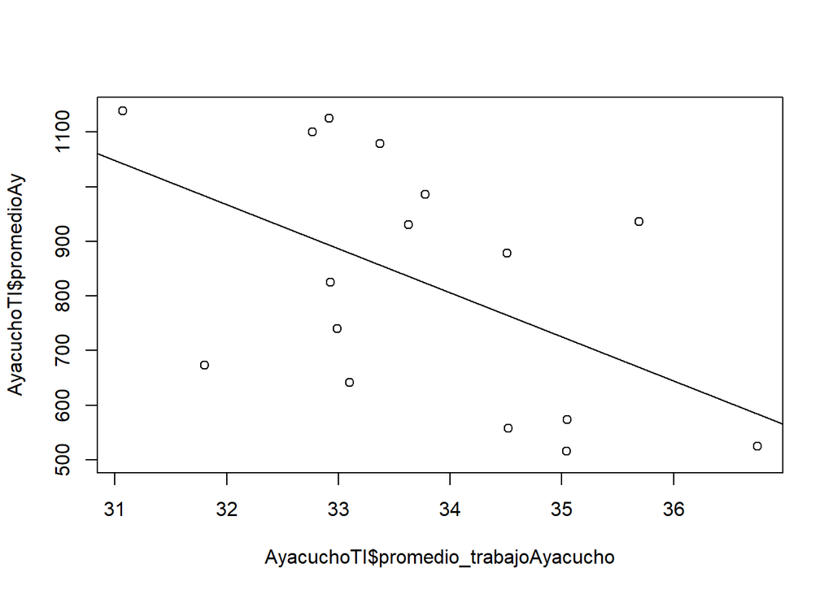

Como se puede observar para Cajamarca, el valor-p es de $0.005$, permitiendo concluir que se rechaza la $H_0$. En base al valor de $r^2$, se puede concluir que alrededor del $43.9$% de la variabilidad del ingreso promedio mensual se puede explicar con el año de la encuesta.

```
##
## Call:
## lm(formula = promedioCa ~ promedio_trabajoCajamarca, data = CajamarcaTI)
##
## Residuals:
##     Min      1Q  Median      3Q     Max
## -294.68 -148.88  -60.74  173.09  327.99
##
## Coefficients:
##                           Estimate Std. Error t value Pr(>|t|)
## (Intercept)                3739.78     864.83   4.324  0.00070 ***
## promedio_trabajoCajamarca   -97.28      29.38  -3.311  0.00515 **
## ---
## Signif. codes:  0 '***' 0.001 '**' 0.01 '*' 0.05 '.' 0.1 ' ' 1
##
## Residual standard error: 199.2 on 14 degrees of freedom
##   (1 observation deleted due to missingness)
## Multiple R-squared:  0.4391, Adjusted R-squared:  0.3991
## F-statistic: 10.96 on 1 and 14 DF,  p-value: 0.00515
```

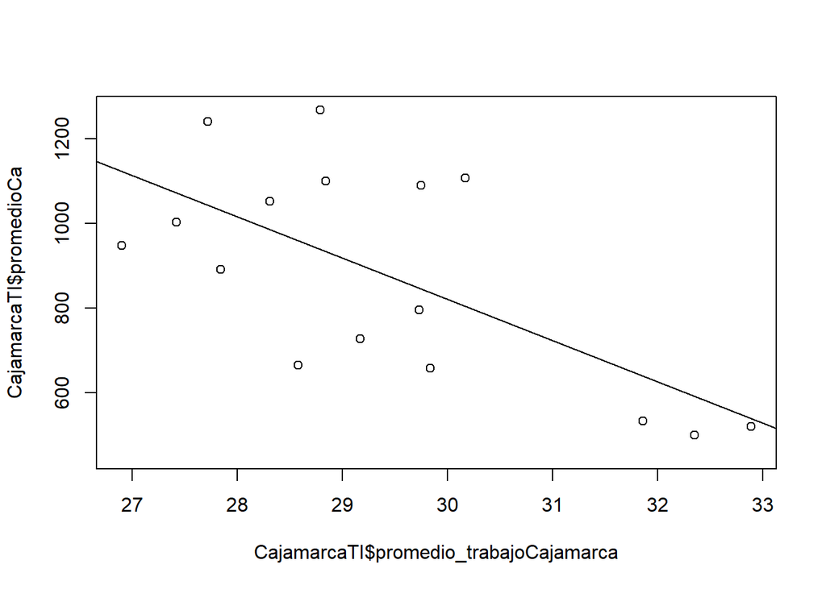

Como se puede observar para Callao, el valor-p es de $0.003$, permitiendo concluir que se rechaza la $H_0$. En base al valor de $r^2$, se puede concluir que alrededor del $47.5$% de la variabilidad del ingreso promedio mensual se puede explicar con el año de la encuesta.

```
##
## Call:
## lm(formula = promedioCall ~ promedio_trabajoCallao, data = CallaoTI)
##
## Residuals:
##    Min     1Q Median     3Q    Max
## -333.7 -155.0  -22.6  218.3  287.8
##
## Coefficients:
##                        Estimate Std. Error t value Pr(>|t|)
## (Intercept)             5139.02    1113.10   4.617 0.000399 ***
## promedio_trabajoCallao   -91.28      25.65  -3.559 0.003144 **
## ---
## Signif. codes:  0 '***' 0.001 '**' 0.01 '*' 0.05 '.' 0.1 ' ' 1
##
## Residual standard error: 218.5 on 14 degrees of freedom
##   (1 observation deleted due to missingness)
## Multiple R-squared:  0.475,  Adjusted R-squared:  0.4375
## F-statistic: 12.67 on 1 and 14 DF,  p-value: 0.003144
```

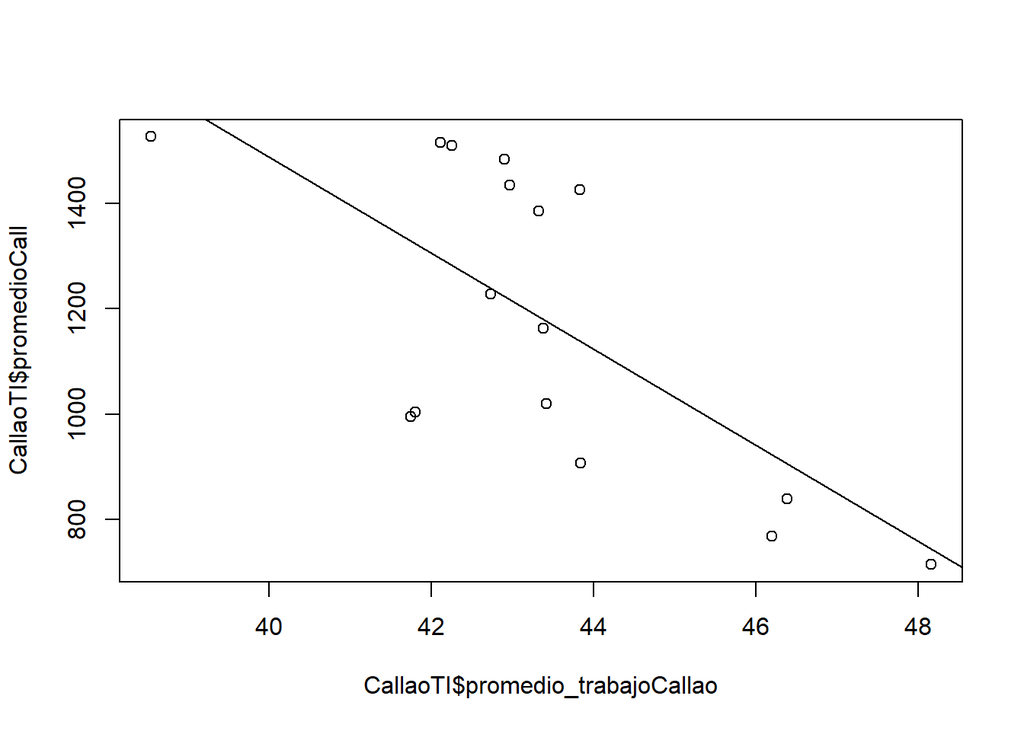

```
##
## Call:
## lm(formula = promedioCus ~ promedio_trabajoCusco, data = CuscoTI)
##
## Residuals:
##     Min      1Q  Median      3Q     Max
## -228.51 -138.64  -17.84   55.41  506.80
##
## Coefficients:
##                       Estimate Std. Error t value Pr(>|t|)
## (Intercept)            5134.48     877.59   5.851 4.21e-05 ***
## promedio_trabajoCusco  -120.40      25.44  -4.734  0.00032 ***
## ---
## Signif. codes:  0 '***' 0.001 '**' 0.01 '*' 0.05 '.' 0.1 ' ' 1
##
## Residual standard error: 203.3 on 14 degrees of freedom
##   (1 observation deleted due to missingness)
## Multiple R-squared:  0.6155, Adjusted R-squared:  0.588
## F-statistic: 22.41 on 1 and 14 DF,  p-value: 0.0003202
```

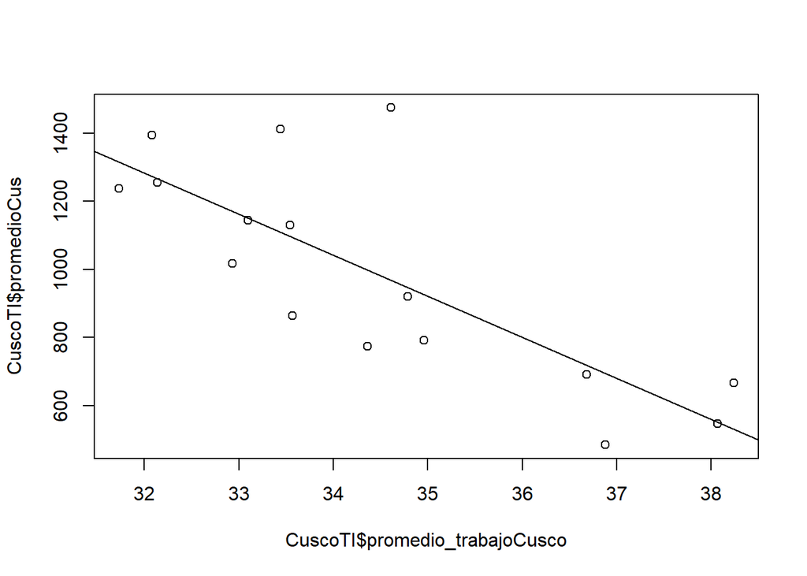

Como se puede observar para Huancavelica, el valor-p es de $0.00002$, permitiendo concluir que se rechaza la $H_0$. En base al valor de $r^2$, se puede concluir que alrededor del $73.5$% de la variabilidad del ingreso promedio mensual se puede explicar con el año de la encuesta.

```
##
## Call:
## lm(formula = promedioHua ~ promedio_trabajoHuancavelica, data = HuancavelicaTI)
##
## Residuals:
##     Min      1Q  Median      3Q     Max
## -155.41  -67.20   16.66   75.01   93.25
##
## Coefficients:
##                              Estimate Std. Error t value Pr(>|t|)
## (Intercept)                   3473.86     421.44   8.243 9.65e-07 ***
## promedio_trabajoHuancavelica   -87.45      14.05  -6.223 2.22e-05 ***
## ---
## Signif. codes:  0 '***' 0.001 '**' 0.01 '*' 0.05 '.' 0.1 ' ' 1
##
## Residual standard error: 82.78 on 14 degrees of freedom
##   (1 observation deleted due to missingness)
## Multiple R-squared:  0.7345, Adjusted R-squared:  0.7155
## F-statistic: 38.73 on 1 and 14 DF,  p-value: 2.225e-05
```

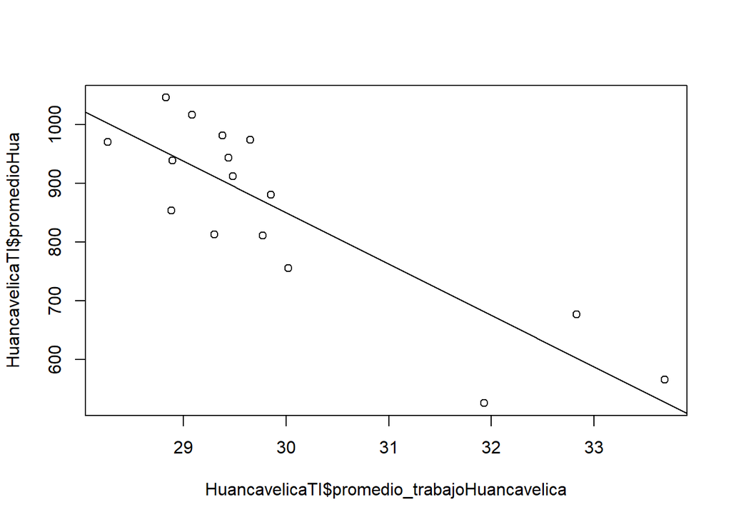

Como se puede observar para Huánuco, el valor-p es de $0.92$, permitiendo concluir que no se rechaza la $H_0$. En base al valor de $r^2$, se puede concluir que alrededor del $0.08$% de la variabilidad del ingreso promedio mensual se puede explicar con el año de la encuesta.

```
##
## Call:
## lm(formula = promedioHua ~ promedio_trabajoHuanuco, data = HuanucoTI)
##
## Residuals:
##     Min      1Q  Median      3Q     Max
## -331.65  -52.05   35.78  116.07  193.28
##
## Coefficients:
##                         Estimate Std. Error t value Pr(>|t|)
## (Intercept)              692.838   1494.349   0.464    0.650
## promedio_trabajoHuanuco    5.384     49.818   0.108    0.915
##
## Residual standard error: 160.6 on 14 degrees of freedom
##   (1 observation deleted due to missingness)
## Multiple R-squared:  0.0008337,  Adjusted R-squared:  -0.07054
## F-statistic: 0.01168 on 1 and 14 DF,  p-value: 0.9155
```

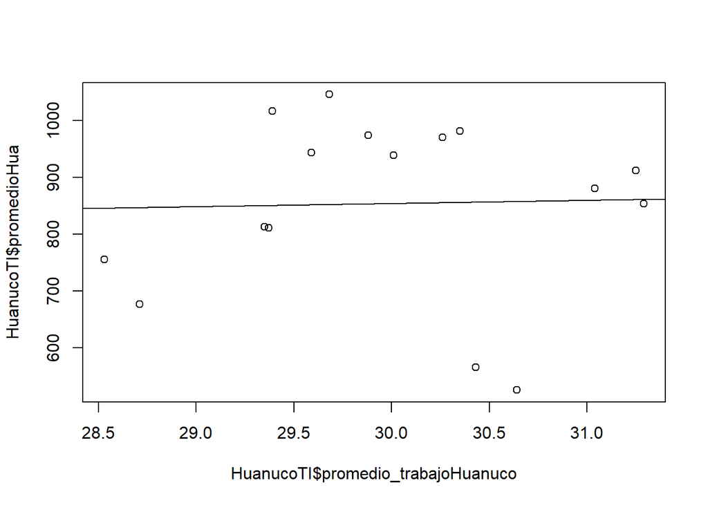

Como se puede observar para Ica, el valor-p es de $0.123$, permitiendo concluir que no se rechaza la $H_0$. En base al valor de $r^2$, se puede concluir que alrededor del $16.2$% de la variabilidad del ingreso promedio mensual se puede explicar con el año de la encuesta.

```
##
## Call:
## lm(formula = promedioI ~ promedio_trabajoIca, data = IcaTI)
##
## Residuals:
##     Min      1Q  Median      3Q     Max
## -364.34 -153.75   -8.98  153.97  703.46
##
## Coefficients:
##                     Estimate Std. Error t value Pr(>|t|)
## (Intercept)         -2228.05    1978.27  -1.126    0.279
## promedio_trabajoIca    78.38      47.70   1.643    0.123
##
## Residual standard error: 283.5 on 14 degrees of freedom
##   (1 observation deleted due to missingness)
## Multiple R-squared:  0.1617, Adjusted R-squared:  0.1018
## F-statistic:   2.7 on 1 and 14 DF,  p-value: 0.1226
```

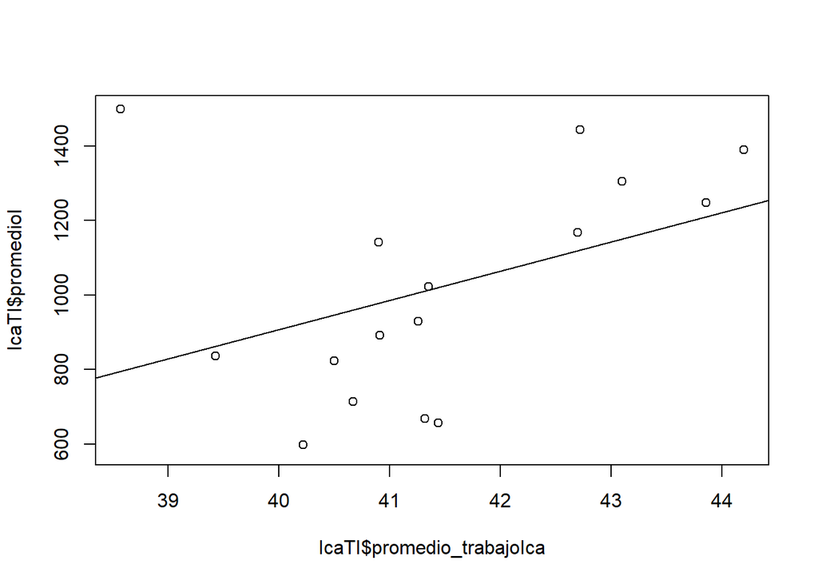

Como se puede observar para Junin, el valor-p es de $0.00007$, permitiendo concluir que se rechaza la $H_0$. En base al valor de $r^2$, se puede concluir que alrededor del $68.5$% de la variabilidad del ingreso promedio mensual se puede explicar con el año de la encuesta.

```
##
## Call:
## lm(formula = promedioJu ~ promedio_trabajoJunin, data = JuninTI)
##
## Residuals:
##     Min      1Q  Median      3Q     Max
## -251.18  -57.41   30.29   99.66  170.62
##
## Coefficients:
##                       Estimate Std. Error t value Pr(>|t|)
## (Intercept)            7132.20    1121.88   6.357 1.78e-05 ***
## promedio_trabajoJunin  -167.41      30.32  -5.521 7.54e-05 ***
## ---
## Signif. codes:  0 '***' 0.001 '**' 0.01 '*' 0.05 '.' 0.1 ' ' 1
##
## Residual standard error: 133.9 on 14 degrees of freedom
##   (1 observation deleted due to missingness)
## Multiple R-squared:  0.6852, Adjusted R-squared:  0.6628
## F-statistic: 30.48 on 1 and 14 DF,  p-value: 7.539e-05
```

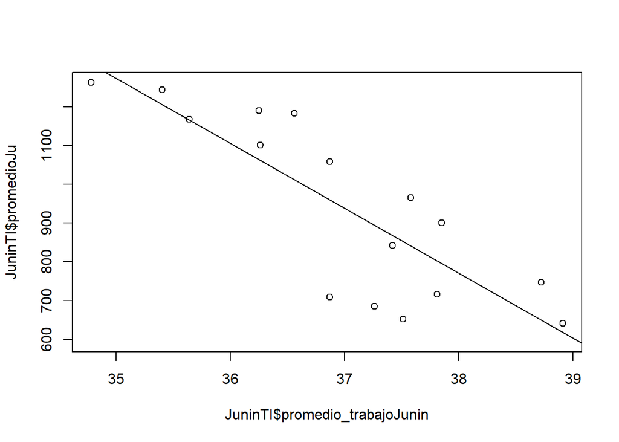

```
##
## Call:
## lm(formula = promedioLa ~ promedio_trabajoLalibertad, data = LalibertadTI)
##
## Residuals:
##     Min      1Q  Median      3Q     Max
## -173.05  -60.72  -11.95   68.84  174.85
##
## Coefficients:
##                            Estimate Std. Error t value Pr(>|t|)
## (Intercept)                 4516.17     473.60   9.536 3.11e-07 ***
## promedio_trabajoLalibertad   -95.79      12.72  -7.530 4.31e-06 ***
## ---
## Signif. codes:  0 '***' 0.001 '**' 0.01 '*' 0.05 '.' 0.1 ' ' 1
##
## Residual standard error: 106.8 on 13 degrees of freedom
##   (2 observations deleted due to missingness)
## Multiple R-squared:  0.8135, Adjusted R-squared:  0.7992
## F-statistic: 56.71 on 1 and 13 DF,  p-value: 4.309e-06
```

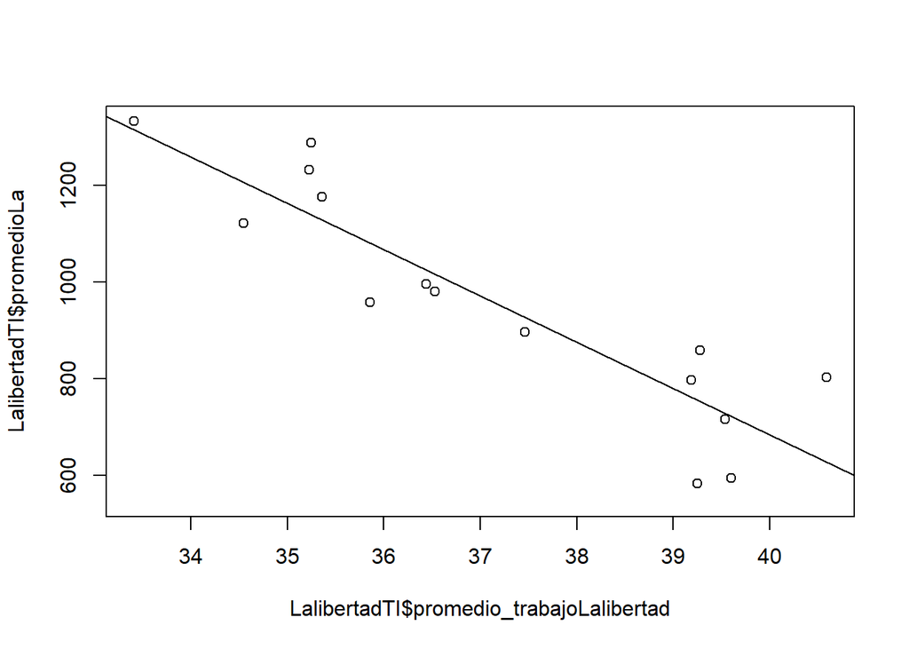

Como se puede observar para Lambayeque, el valor-p es de $0.9$, permitiendo concluir que no se rechaza la $H_0$. En base al valor de $r^2$, se puede concluir que alrededor del $0.1$% de la variabilidad del ingreso promedio mensual se puede explicar con el año de la encuesta.

```
##
## Call:
## lm(formula = promedioLam ~ promedio_trabajoLambayeque, data = LambayequeTI)
##
## Residuals:
##     Min      1Q  Median      3Q     Max
## -391.35 -215.89    8.04  265.79  387.37
##
## Coefficients:
##                            Estimate Std. Error t value Pr(>|t|)
## (Intercept)                 1086.67    1698.51   0.640    0.533
## promedio_trabajoLambayeque    -5.50      44.97  -0.122    0.904
##
## Residual standard error: 274.6 on 14 degrees of freedom
##   (1 observation deleted due to missingness)
## Multiple R-squared:  0.001068,   Adjusted R-squared:  -0.07028
## F-statistic: 0.01496 on 1 and 14 DF,  p-value: 0.9044
```

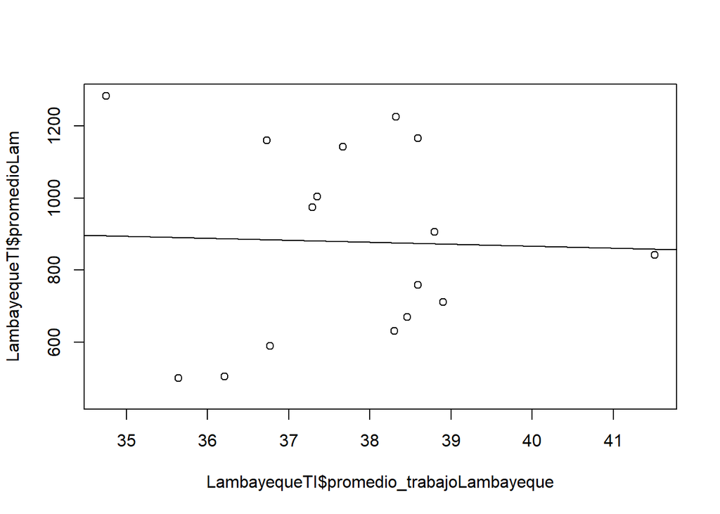

Como se puede observar para Lima, el valor-p es de $0.0001$, permitiendo concluir que se rechaza la $H_0$. En base al valor de $r^2$, se puede concluir que alrededor del $64.3$% de la variabilidad del ingreso promedio mensual se puede explicar con el año de la encuesta.

```
## [1] 17
```

```
##
## Call:
## lm(formula = promedioLi ~ promedio_trabajoLima, data = LiTI)
##
## Residuals:
##     Min      1Q  Median      3Q     Max
## -307.33 -147.37  -21.35  195.09  324.73
##
## Coefficients:
##                      Estimate Std. Error t value Pr(>|t|)
## (Intercept)           6232.17     980.16   6.358 1.77e-05 ***
## promedio_trabajoLima  -115.06      22.93  -5.019 0.000188 ***
## ---
## Signif. codes:  0 '***' 0.001 '**' 0.01 '*' 0.05 '.' 0.1 ' ' 1
##
## Residual standard error: 214.8 on 14 degrees of freedom
##   (1 observation deleted due to missingness)
## Multiple R-squared:  0.6427, Adjusted R-squared:  0.6172
## F-statistic: 25.19 on 1 and 14 DF,  p-value: 0.0001879
```

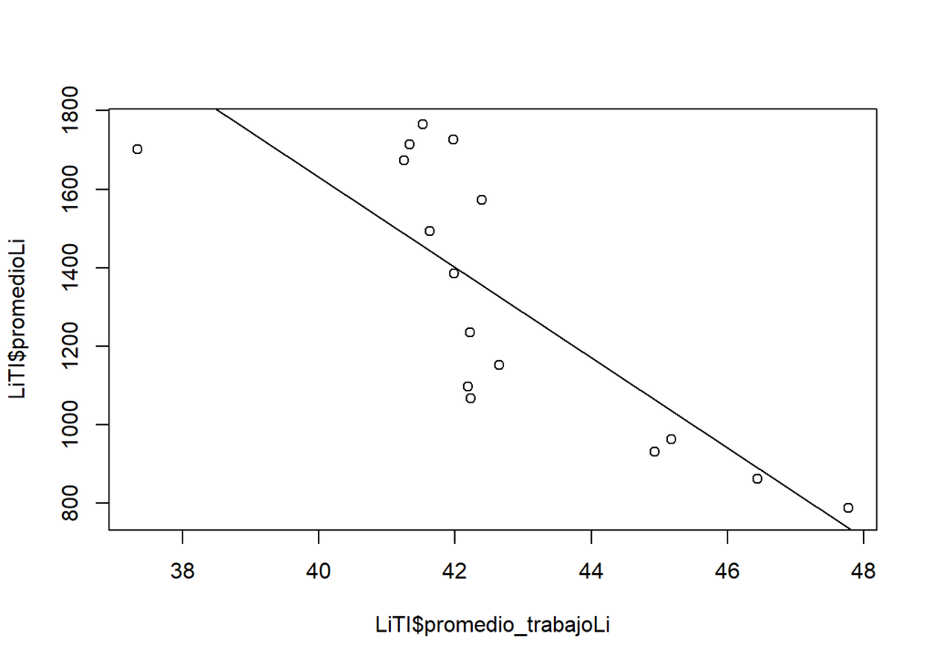

Como se puede observar para Loreto, el valor-p es de $0.0001$, permitiendo concluir que se rechaza la $H_0$. En base al valor de $r^2$, se puede concluir que alrededor del $67.2$% de la variabilidad del ingreso promedio mensual se puede explicar con el año de la encuesta.

```
##
## Call:
## lm(formula = promedioLor ~ promedio_trabajoLoreto, data = LoretoTI)
##
## Residuals:
##     Min      1Q  Median      3Q     Max
## -350.24 -168.87    0.29  141.66  310.25
##
## Coefficients:
##                        Estimate Std. Error t value Pr(>|t|)
## (Intercept)             6818.62    1078.88   6.320 1.89e-05 ***
## promedio_trabajoLoreto  -174.79      32.64  -5.355 0.000101 ***
## ---
## Signif. codes:  0 '***' 0.001 '**' 0.01 '*' 0.05 '.' 0.1 ' ' 1
##
## Residual standard error: 198.6 on 14 degrees of freedom
##   (1 observation deleted due to missingness)
## Multiple R-squared:  0.672,  Adjusted R-squared:  0.6485
## F-statistic: 28.68 on 1 and 14 DF,  p-value: 0.0001015
```